# AsMi_annual report

Michelle DePrenger-Levin

Tuesday, October 27, 2015

The git remote is “AsMiPVA” AsMiPVA

```r
#install.packages("ggplot2")
library(reshape2)
library(ggplot2)
library(psych)
library(popbio)
library(devtools)
library(sciplot)
library(plotrix)
library(scales)
library(plyr)
#library(lattice)
#library(latticeExtra)
library(devtools)
library(digest)
library(RCurl)
#source_url("http://cran.r-project.org/bin/windows/Rtools/") #and then run find_rtools()
# source_url("https://raw.github.com/JoFrhwld/FAAV/master/r/stat-ellipse.R")
# Seems no longer supported. Use ggplot stat_ellipse instead (with colour = for designating circles)

library(prism)
library(rgdal)
library(raster)
#library(car)
#install.packages("ellipse")
#library(ellipse)
```

Remove all variables, keep functions

```r
rm(list = setdiff(ls(), lsf.str()))
```

summarySE function borrowed from http://www.cookbook-r.com/Manipulating_data/Summarizing_data/  
Function for t.tests, for annual lambdas

```r
summarySE <- function(data=NULL, measurevar, groupvars=NULL, na.rm=FALSE,
                      conf.interval=.95, .drop=TRUE) {
    library(plyr)

    # New version of length which can handle NA's: if na.rm==T, don't count them
    length2 <- function (x, na.rm=FALSE) {
        if (na.rm) sum(!is.na(x))
        else       length(x)
    }

    # This does the summary. For each group's data frame, return a vector with
    # N, mean, and sd
    datac <- ddply(data, groupvars, .drop=.drop,
      .fun = function(xx, col) {
        c(N    = length2(xx[[col]], na.rm=na.rm),
          mean = mean   (xx[[col]], na.rm=na.rm),
          sd   = sd     (xx[[col]], na.rm=na.rm)
        )
      },
      measurevar
    )

    # Rename the "mean" column
    datac <- rename(datac, c("mean" = measurevar))

    datac$se <- datac$sd / sqrt(datac$N)  # Calculate standard error of the mean

    # Confidence interval multiplier for standard error
    # Calculate t-statistic for confidence interval:
    # e.g., if conf.interval is .95, use .975 (above/below), and use df=N-1
    ciMult <- qt(conf.interval/2 + .5, datac$N-1)
    datac$ci <- datac$se * ciMult

    return(datac)
}

#Function for t.tests, for annual lambdas

lmdAn <- function(x,y,z){

  yrs <- 1995:z
    st <- match(c(y,z),yrs)

    lambdaAll <- c()
    for(i in c(y:z)){
        lambdaAll <- cbind(lambdaAll,eigen.analysis(x[[as.character(i)]])$lambda)
    }
    lambdaAll
}

# StagePVA_Function.R
script <- getURL("https://raw.githubusercontent.com/DenverBotanicGardens/PVA/master/StagePVA_Function.R",ssl.verifypeer = FALSE)
eval(parse(text = script))
```

requires library(popbio)  
x is the list of matrices, i.e. notfenced.Site.matrix$"26", or fenced.Site.matrix$“19”[2:17])  
y is the start year  
z is the start of the last transition

```r
lmdSD <- function(x,y,z){

  startyr <- min(as.numeric(names(x)))
    yrs <- startyr:z
    st <- match(c(y,z),yrs)

    lambdaAll <- c()
    for(i in c(y:z)){
        lambdaAll <- cbind(lambdaAll,eigen.analysis(x[[as.character(i)]])$lambda)
    }
    StandDev <- sqrt(var(c(lambdaAll))) #Standard Deviation
    cbind(lmda = lambda(mean(x[st[1]:st[2]])),SD = StandDev)
}
```

# Download raw_data

https://research.botanicgardens.org/admin/demographics/asmi/reports/raw_data.php  
Save all sites, all data, and set to 20 years allowed dormant  
Put the new data in folder currentyr_asmi and name it RawData_currentyr

```r
currentyr <- as.numeric(format(as.Date(Sys.Date(),format="%Y-%m-%d"), "%Y"))
rawdatapath <- paste("Q:/Research/All_Projects_by_Species/Astragalus SPECIES/Astragalus_microcymbus/Asmi_Excel/Yearly Summaries/",
                     currentyr,"_asmi/RawData_",
                     currentyr, ".csv", collapse = '', sep = '')

asmi.raw <- read.csv(path.expand(rawdatapath), na.strings = "na")

# No longer adding climate data to the database
asmi.raw <- asmi.raw[,grep(paste(c("Temp","Rain","Snow","Aug.Jul"),collapse="|"), names(asmi.raw),
                           value = TRUE, invert = TRUE)]

table(asmi.raw$year, asmi.raw$AsMi_site_id)
```

```
##
##          1   2   5  15  19  26
##   1995   0   0  96 185 177 336
##   1996   0   0  96 195 194 399
##   1997   0   0  68 202 231 304
##   1998   0   0  71 185 213 261
##   1999   0   0  61 150 159 207
##   2000   0   0  57 139 163 191
##   2001   0   0  58 117 170 174
##   2002   0   0  55  99 150 143
##   2003   0   0  42  95 125 120
##   2004   0   0  43 108 163 155
##   2005   0   0  38 110 170 157
##   2006   0   0  42 124 178 167
##   2007   0   0  47 124 173 174
##   2008   0   0  45 132 170 194
##   2009   0   0  50 149 192 275
##   2010   0   0  51 148 184 274
##   2011   0   0  38 135 169 240
##   2012   0   0  22 111 127 191
##   2013   0   0  15  59  65  68
##   2014 128  89  15  74 117  73
##   2015 392 319  18 120 189 166
##   2016 357 390  17 131 245 201
```

```r
table(asmi.raw$year, asmi.raw$AsMi_plot_id)
```

```
##
##          1   8  16  22  32  42  52  58  89  90  96  98 238 300 480 512 513
##   1995   0 103   0   0   0   0   0   0   0   0   0   0   0   0  84  39  28
##   1996   0 104   0   0   0   0   0   0   0   0   0   0  55  12  87  40  28
##   1997   0  87   0   0   0   0   0   0   0   0   0   0  60  61  59  46  20
##   1998   0  77   0   0   0   0   0   0   0   0   0   0  48  59  53  41  16
##   1999   0  61   0   0   0   0   0   0   0   0   0   0  40  43  41  28  15
##   2000   0  58   0   0   0   0   0   0   0   0   0   0  36  51  39  29  12
##   2001   0  52   0   0   0   0   0   0   0   0   0   0  28  50  34  32  16
##   2002   0  46   0   0   0   0   0   0   0   0   0   0  25  43  25  30  14
##   2003   0  45   0   0   0   0   0   0   0   0   0   0  20  44  18  25  10
##   2004   0  49   0   0   0   0   0   0   0   0   0   0  22  58  18  34  15
##   2005   0  49   0   0   0   0   0   0   0   0   0   0  22  62  18  29  17
##   2006   0  61   0   0   0   0   0   0   0   0   0   0  29  65  24  30  16
##   2007   0  63   0   0   0   0   0   0   0   0   0   0  34  61  32  31  16
```

[output cut: 33 more lines]

```r
table(asmi.raw$Browsing...Status)
```

```
##
##                              Insect            mammal            Mammal
##                 1               457                 1              1004
## Mammal and Insect              None     Yes - Unknown
##                77             10878              1145
```

```r
#asmi.raw <- transform(asmi.raw, year = as.numeric(year))
str(asmi.raw)
```

```
## 'data.frame':    13807 obs. of  20 variables:
##  $ AsMi_data_id     : int  39513 40216 39514 40217 39515 40218 39516 40219 39517 40220 ...
##  $ AsMi_tag_id      : int  2471 2471 2472 2472 2473 2473 2474 2474 2475 2475 ...
##  $ year             : int  2015 2016 2015 2016 2015 2016 2015 2016 2015 2016 ...
##  $ length           : num  6 0 7 0 5 0 5 0 4 13 ...
##  $ flower           : int  0 0 0 0 0 0 0 0 0 0 ...
##  $ fruit            : int  0 0 0 0 0 0 0 0 0 0 ...
##  $ browsing         : int  0 0 0 0 0 0 1 0 1 0 ...
##  $ Browsing...Status: Factor w/ 7 levels "","Insect","mammal",..: 6 6 6 6 6 6 4 6 2 6 ...
##  $ status           : Factor w/ 6 levels "","dead","dormant",..: 5 2 5 2 5 2 5 2 5 6 ...
##  $ comments         : Factor w/ 731 levels ""," "," mammal",..: 441 441 441 441 441 441 365 441 313 441 ...
##  $ tag_no           : num  20 20 20 20 20 ...
##  $ AsMi_plot_id     : int  1 1 1 1 1 1 1 1 1 1 ...
##  $ AsMi_site_id     : int  1 1 1 1 1 1 1 1 1 1 ...
##  $ fence            : Factor w/ 3 levels "","n","y": 2 2 2 2 2 2 2 2 2 2 ...
##  $ plotlocation     : Factor w/ 3 levels "","424797.122, 312437.827",..: 3 3 3 3 3 3 3 3 3 3 ...
##  $ location         : Factor w/ 1426 levels ""," "," there are two - 2014 swapped from 327 at 2.69 SE to 1197",..: 548 548 1167 1167 716 716 527 527 667 667 ...
##  $ direction        : Factor w/ 19 levels "","E","E ","ENE",..: 10 10 15 15 15 15 10 10 10 10 ...
##  $ direction.1      : num  315 315 225 225 225 225 315 315 315 315 ...
##  $ distance         : num  2.94 2.94 2.94 2.94 2.94 2.94 0.79 0.79 0.79 0.79 ...
##  $ invalid_tag      : logi  FALSE FALSE FALSE FALSE FALSE FALSE ...
```

```r
table(asmi.raw$AsMi_plot_id,asmi.raw$AsMi_site_id)
```

```
##
##          1    2    5   15   19   26
##   1    213    0    0    0    0    0
##   8      0    0    0 1472    0    0
##   16     0  156    0    0    0    0
##   22   217    0    0    0    0    0
##   32   188    0    0    0    0    0
##   42   153    0    0    0    0    0
##   52   106    0    0    0    0    0
##   58     0  101    0    0    0    0
##   89     0  169    0    0    0    0
##   90     0  133    0    0    0    0
##   96     0   72    0    0    0    0
##   98     0  167    0    0    0    0
##   238    0    0    0    0    0  787
```

[output cut: 17 more lines]

```r
# one blank row at the end of the csv download
asmi.raw[asmi.raw$status == "",]
```

```
##       AsMi_data_id AsMi_tag_id year length flower fruit browsing
## 13807           NA          NA   NA     NA     NA    NA       NA
##       Browsing...Status status comments tag_no AsMi_plot_id AsMi_site_id
## 13807                                       NA           NA           NA
##       fence plotlocation location direction direction.1 distance
## 13807                                                NA       NA
##       invalid_tag
## 13807          NA
```

```r
asmi.raw <- asmi.raw[asmi.raw$status != "",]
asmi.raw$status <- factor(asmi.raw$status)
table(asmi.raw$status)
```

```
##
##         dead      dormant reproductive     seedling   vegetative
##         2237         4337         2046         2233         2953
```

```r
#reset factors of browsing to eliminate " "
asmi.raw$Browsing...Status[asmi.raw$Browsing...Status == "mammal"] <- "Mammal"
asmi.raw$Browsing...Status <- factor(asmi.raw$Browsing...Status)

#reset factors for fence
asmi.raw$fence <- factor(asmi.raw$fence)
table(asmi.raw$fence)
```

```
##
##     n     y
## 10080  3726
```

Table 1:Demographic data of Astragalus microcymbus within the South Beaver Creek and Cebolla Creek drainages near Gunnison, Colorado. (a) Average number of individuals with above ground growth (AGG) followed by total individuals (AGG and dormant) per plot. (b) Percent of reproductive individuals followed by average reproductive individuals per plot. Site 1 is Cebolla Creek Mid and site 2 is Cebolla Creek north. Standard errors are shown in parentheses.

```r
#AGG
alive <-aggregate(length ~ AsMi_plot_id + year + AsMi_site_id + fence,
                  data = asmi.raw, function(x) length(x[x>0 & !is.na(x)]))

#AGG and dormant
aggdorm <- aggregate(status ~ AsMi_plot_id +year + AsMi_site_id  + fence,
                     data = asmi.raw, function(x) length(x[x != "dead" & !is.na(x)]))
```

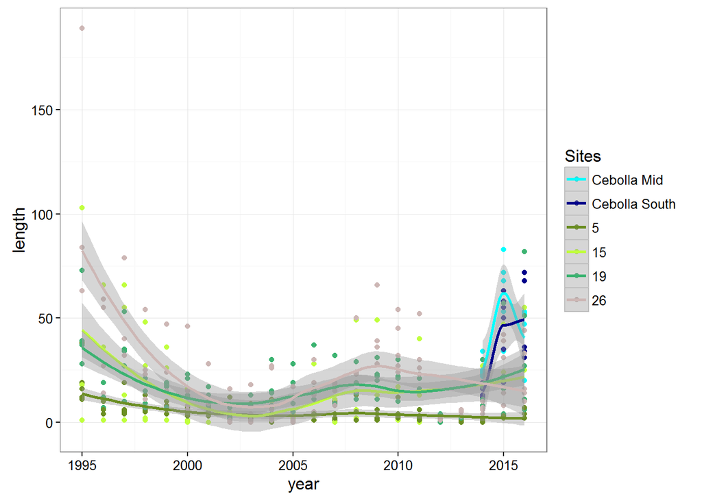

```r
ggplot(alive, aes(year, length, colour=as.factor(AsMi_site_id)))+
  geom_point()+
  stat_smooth()+
  theme_bw()+
  scale_color_manual("Sites",labels = c("Cebolla Mid",
                                          "Cebolla South",
                                          "5","15","19","26"),
                     values = c("cyan", "darkblue",
                                "olivedrab","olivedrab1",
                                "mediumseagreen","mistyrose3"))
```

```r
tbl1a.1 <- summarySE(alive, measurevar="length", groupvars=c("AsMi_site_id", "year"))

tbl1a.2 <- summarySE(aggdorm, measurevar="status", groupvars=c("AsMi_site_id", "year"))

sites <- unique(tbl1a.1$AsMi_site_id)

tbl1.1 <- lapply(sites, function(x){
  paste(round(tbl1a.1[tbl1a.1$AsMi_site_id == x,"length"],2)," (",
        round(tbl1a.1[tbl1a.1$AsMi_site_id == x,"se"],2), ")", sep="")
})

tbl1.2 <- lapply(sites, function(x){
  paste(round(tbl1a.2[tbl1a.2$AsMi_site_id == x,"status"],2)," (",
        round(tbl1a.2[tbl1a.2$AsMi_site_id == x,"se"],2), ")", sep="")
})

tbl1a <- lapply(1:6, function(x){
  data.frame(tbl1.1[[x]],tbl1.2[[x]])
  })

#Cebolla Mid, Site 1
tbl1a[[1]]
```

```
##   tbl1.1..x.. tbl1.2..x..
## 1 25.6 (2.16) 25.6 (2.16)
## 2   62 (8.49) 63.2 (8.81)
## 3 40.6 (6.49) 40.6 (6.49)
```

```r
write.table(tbl1a[[1]], "clipboard", sep="\t", row.names=FALSE, col.names = FALSE)

#Cebolla North, Site 2
tbl1a[[2]]
```

```
##    tbl1.1..x..  tbl1.2..x..
## 1 14.83 (1.54) 14.83 (1.54)
## 2 46.67 (6.78)   48.5 (6.8)
## 3  49.33 (7.4)  49.33 (7.4)
```

```r
write.table(tbl1a[[2]], "clipboard", sep="\t", row.names=FALSE, col.names = FALSE)

#South Beaver Creek, Site 5
tbl1a[[3]]
```

```
##    tbl1.1..x.. tbl1.2..x..
## 1  19.2 (4.91) 19.2 (4.91)
## 2     5 (1.48) 10.6 (1.83)
## 3   8.8 (2.75) 12.4 (3.17)
## 4   6.6 (1.81) 11.8 (2.69)
## 5   6.4 (1.17) 10.8 (1.83)
## 6   4.6 (0.81)  9.6 (2.16)
## 7   7.4 (2.48)   11 (3.56)
## 8   4.2 (1.98)  8.2 (3.54)
## 9   3.2 (1.59)    7 (2.59)
## 10  3.6 (1.94)  7.6 (3.17)
## 11   0.4 (0.4)  5.6 (2.44)
## 12  4.4 (2.71)  8.4 (3.83)
## 13  3.8 (1.62)   8.6 (3.5)
## 14   4.6 (2.2)  8.2 (3.72)
## 15  7.2 (4.04)  9.6 (4.88)
## 16    5 (1.79)  7.4 (3.14)
## 17    3 (0.84)  4.4 (1.54)
## 18   0.6 (0.4)  2.8 (0.97)
## 19  0.8 (0.37)  2.8 (0.97)
## 20  1.8 (1.11)  2.6 (1.21)
## 21 2.75 (0.48)  3.5 (0.87)
## 22 3.75 (1.18) 3.75 (1.18)
```

```r
write.table(tbl1a[[3]], "clipboard", sep="\t", row.names=FALSE, col.names = FALSE)
#South Beaver Creek, Site 15
tbl1a[[4]]
```

```
##      tbl1.1..x..   tbl1.2..x..
## 1     46.25 (23)    46.25 (23)
## 2  26.75 (15.29) 36.25 (18.69)
## 3   33.75 (15.8) 44.25 (20.09)
## 4   19.5 (11.24)  36.5 (17.33)
## 5     21 (10.41) 34.25 (15.93)
## 6       8 (4.34)  27.75 (12.2)
## 7       4 (1.87) 24.75 (10.25)
## 8    1.75 (1.11)   23.5 (9.79)
## 9    1.25 (0.63)      23 (9.6)
## 10   6.25 (1.89)    27 (10.84)
## 11      5 (1.47)   26.5 (10.7)
## 12  12.75 (6.49) 29.75 (13.17)
## 13      8 (3.76)    28 (12.81)
## 14    18 (10.68)  31.5 (15.12)
## 15   18.5 (10.5) 33.25 (16.24)
## 16   19.5 (9.22)    32 (14.65)
## 17     19 (8.44) 27.75 (13.04)
## 18   0.67 (0.33) 19.33 (10.11)
## 19   2.33 (1.45) 19.33 (10.11)
## 20     12 (7.77)    24 (13.58)
## 21 26.33 (11.32) 36.33 (16.76)
## 22       29 (14)       29 (14)
```

```r
write.table(tbl1a[[4]], "clipboard", sep="\t", row.names=FALSE, col.names = FALSE)
#South Beaver Creek, Site 19
tbl1a[[5]]
```

```
##     tbl1.1..x..  tbl1.2..x..
## 1  44.25 (9.88) 44.25 (9.88)
## 2   15.4 (3.47)  24.8 (6.04)
## 3   31.8 (6.94)  41.6 (7.49)
## 4   14.6 (2.93)  31.4 (5.44)
## 5    13.8 (2.6)  28.2 (5.27)
## 6     15 (3.11)  29.8 (5.82)
## 7   12.2 (1.53)  29.2 (5.27)
## 8    2.2 (1.24)  22.8 (4.53)
## 9    5.2 (2.33)  24.6 (5.78)
## 10  14.2 (4.43)    31 (6.76)
## 11  12.4 (4.92)  30.8 (6.18)
## 12  17.4 (5.52)  32.8 (7.37)
## 13   15.4 (4.5)  31.8 (6.84)
## 14  16.8 (3.38)    32 (5.65)
## 15   21.4 (3.2)  34.6 (5.08)
## 16  20.8 (3.18)  30.8 (4.45)
## 17   17.6 (1.4)  25.4 (3.04)
## 18     1 (0.77)  12.4 (2.87)
## 19    2.2 (0.2)    12 (2.47)
## 20  15.2 (3.99)  23.4 (6.25)
## 21  23.8 (8.87)   31 (10.51)
## 22 35.4 (14.04) 35.4 (14.04)
```

```r
write.table(tbl1a[[5]], "clipboard", sep="\t", row.names=FALSE, col.names = FALSE)
#South Beaver Creek, Site 26
tbl1a[[6]]
```

```
##      tbl1.1..x..   tbl1.2..x..
## 1    112 (38.97)   112 (38.97)
## 2   38.75 (10.9)    65 (19.13)
## 3  47.75 (10.59)  64.5 (17.65)
## 4   28.25 (9.12)     51 (14.9)
## 5    27.5 (6.84)    47 (13.62)
## 6   18.75 (9.29) 38.75 (13.88)
## 7   14.25 (4.59)  35.5 (11.52)
## 8    5.25 (3.68) 28.75 (10.78)
## 9    5.75 (4.17)    29 (11.03)
## 10   12.4 (5.82)     30 (9.92)
## 11    6.6 (3.36)   27.2 (8.25)
## 12   16.2 (4.12)   31.6 (8.64)
## 13   12.8 (2.92)     32 (8.29)
## 14     27 (5.97)   37.6 (9.72)
## 15     40 (6.77)    51 (10.73)
## 16   36.4 (5.68)   47.2 (9.79)
## 17   32.2 (5.12)   38.2 (6.92)
## 18     1.4 (0.4)   13.2 (3.95)
## 19    3.8 (0.73)   12.8 (3.81)
## 20    6.6 (0.98)   12.4 (3.88)
## 21   26.8 (6.76)   29.6 (8.56)
## 22   23.4 (6.48)   23.4 (6.48)
```

```r
write.table(tbl1a[[6]], "clipboard", sep="\t", row.names=FALSE, col.names = FALSE)
```

Percent and total preproductive

```r
#precent reproductive, return 0 if no
prep <- aggregate(flower~AsMi_plot_id+year+AsMi_site_id +fence,
                  data = asmi.raw[asmi.raw$length > 0 & !is.na(asmi.raw$length),],
                  function(x){
                    if(length(x)>0){
                      sum(x,na.rm = TRUE)/length(x)
                    } else {
                        0
                      }
                  })
tbl1b.1 <- summarySE(prep, measurevar="flower", groupvars=c("AsMi_site_id","year"))
head(tbl1b.1)
```

```
##   AsMi_site_id year N     flower         sd         se         ci
## 1            1 2014 5 0.05464218 0.03565877 0.01594709 0.04427622
## 2            1 2015 5 0.02320261 0.03829251 0.01712493 0.04754643
## 3            1 2016 5 0.20430898 0.28125177 0.12577962 0.34922020
## 4            2 2014 6 0.13693489 0.12837308 0.05240809 0.13471929
## 5            2 2015 6 0.03297938 0.03055479 0.01247394 0.03206528
## 6            2 2016 6 0.21984703 0.13204710 0.05390800 0.13857494
```

```r
#sites above
#percent reproductive
tbl1.3 <- lapply(sites, function(x){
  paste(round(tbl1b.1[tbl1b.1$AsMi_site_id == x,"flower"],3)*100,"% (",
        round(tbl1b.1[tbl1b.1$AsMi_site_id == x,"se"],3)*100, "%)", sep="")
})

tbl1.3[[3]]
```

```
##  [1] "46.5% (5.1%)"  "0% (0%)"       "49.5% (3.2%)"  "4% (4%)"
##  [5] "5% (5%)"       "2.9% (2.9%)"   "35.3% (10.8%)" "0% (0%)"
##  [9] "14.6% (8.6%)"  "8.3% (8.3%)"   "0% (NA%)"      "22.7% (19.5%)"
## [13] "10% (10%)"     "23.7% (15.9%)" "63.4% (19.4%)" "71.7% (17.4%)"
## [17] "26.7% (19.4%)" "0% (0%)"       "66.7% (33.3%)" "66.7% (16.7%)"
## [21] "27.1% (10.4%)" "34.8% (17%)"
```

```r
#total reproductive
totrep <- aggregate(flower ~ AsMi_plot_id +year + AsMi_site_id  + fence,
                    data = asmi.raw[asmi.raw$length > 0 & !is.na(asmi.raw$length),],
                    function(x) sum(x, na.rm = TRUE))

head(totrep)
```

```
##   AsMi_plot_id year AsMi_site_id fence flower
## 1            1 2014            1     n      2
## 2           22 2014            1     n      0
## 3           32 2014            1     n      2
## 4           42 2014            1     n      2
## 5           52 2014            1     n      1
## 6            1 2015            1     n      0
```

```r
tbl1b.2 <- summarySE(totrep, measurevar="flower",groupvars=c("AsMi_site_id","year"))
tbl1.4 <- lapply(sites, function(x){
  paste(round(tbl1b.2[tbl1b.2$AsMi_site_id == x,"flower"],2)," (",
        round(tbl1b.2[tbl1b.2$AsMi_site_id == x,"se"],2), ")", sep="")
})

tbl1b <- lapply(1:6, function(x){
  data.frame(tbl1.3[[x]], tbl1.4[[x]])
  })

#Cebolla Mid, 1
tbl1b[[1]]
```

```
##     tbl1.3..x.. tbl1.4..x..
## 1   5.5% (1.6%)   1.4 (0.4)
## 2   2.3% (1.7%)    1 (0.63)
## 3 20.4% (12.6%)  5.6 (2.32)
```

```r
write.table(tbl1b[[1]], "clipboard", sep="\t", row.names=FALSE, col.names = FALSE)

#Cebolla North, 2
tbl1b[[2]]
```

```
##    tbl1.3..x..  tbl1.4..x..
## 1 13.7% (5.2%)     2 (0.77)
## 2  3.3% (1.2%)  1.67 (0.67)
## 3   22% (5.4%) 11.17 (2.73)
```

```r
write.table(tbl1b[[2]], "clipboard", sep="\t", row.names=FALSE, col.names = FALSE)

#South Beaver Creek, 5
tbl1b[[3]]
```

```
##      tbl1.3..x.. tbl1.4..x..
## 1   46.5% (5.1%)  9.6 (3.26)
## 2        0% (0%)       0 (0)
## 3   49.5% (3.2%)  4.2 (1.24)
## 4        4% (4%)   0.2 (0.2)
## 5        5% (5%)   0.4 (0.4)
## 6    2.9% (2.9%)   0.2 (0.2)
## 7  35.3% (10.8%)  2.6 (1.17)
## 8        0% (0%)       0 (0)
## 9   14.6% (8.6%)    1 (0.71)
## 10   8.3% (8.3%) 0.25 (0.25)
## 11      0% (NA%)      0 (NA)
## 12 22.7% (19.5%)   0.6 (0.4)
## 13     10% (10%)   0.2 (0.2)
## 14 23.7% (15.9%)  1.8 (1.11)
## 15 63.4% (19.4%)  2.2 (0.73)
## 16 71.7% (17.4%)  2.8 (0.58)
## 17 26.7% (19.4%)   0.6 (0.4)
## 18       0% (0%)       0 (0)
## 19 66.7% (33.3%) 0.67 (0.33)
## 20 66.7% (16.7%) 1.67 (0.67)
## 21 27.1% (10.4%) 0.75 (0.25)
## 22   34.8% (17%) 1.25 (0.63)
```

```r
write.table(tbl1b[[3]], "clipboard", sep="\t", row.names=FALSE, col.names = FALSE)

#South Beaver Creek, 15
tbl1b[[4]]
```

```
##      tbl1.3..x..   tbl1.4..x..
## 1  62.2% (18.6%) 29.25 (16.88)
## 2     20.5% (7%)   7.75 (4.85)
## 3  32.1% (16.9%)    17 (10.11)
## 4  24.1% (13.4%)    3.5 (2.84)
## 5  38.6% (22.2%)  11.33 (5.93)
## 6        0% (0%)         0 (0)
## 7    3.7% (3.7%)   0.33 (0.33)
## 8        0% (0%)         0 (0)
## 9  66.7% (33.3%)   1.33 (0.88)
## 10       0% (0%)         0 (0)
## 11   2.8% (2.8%)   0.25 (0.25)
## 12  19.4% (7.5%)      3 (1.78)
## 13     7% (3.6%)      1 (0.58)
## 14  53.5% (5.6%)   9.75 (6.17)
## 15 42.9% (17.9%)   11.5 (7.47)
## 16 72.4% (14.3%)   11.5 (4.66)
## 17  71.3% (1.9%)  18.33 (6.17)
## 18       0% (0%)         0 (0)
## 19       0% (0%)         0 (0)
## 20 45.7% (29.2%)   3.67 (3.18)
## 21  25.3% (7.4%)   8.33 (5.04)
## 22  36.6% (7.7%)  10.33 (4.26)
```

```r
write.table(tbl1b[[4]], "clipboard", sep="\t", row.names=FALSE, col.names = FALSE)

#South Beaver Creek, 19
tbl1b[[5]]
```

```
##      tbl1.3..x..  tbl1.4..x..
## 1   51.9% (6.7%) 22.25 (4.66)
## 2   17.2% (7.9%)   3.4 (1.83)
## 3   26.3% (9.4%)   9.2 (3.51)
## 4        0% (0%)        0 (0)
## 5   58.9% (8.5%)   8.2 (1.98)
## 6  20.5% (12.3%)   2.4 (1.03)
## 7   28.4% (9.1%)   3.8 (1.62)
## 8        0% (0%)        0 (0)
## 9  41.4% (18.3%)    1.4 (0.4)
## 10    28% (9.9%)   3.2 (1.36)
## 11   39% (19.1%)   2.8 (1.16)
## 12  41.4% (5.6%)     7 (2.61)
## 13  47.8% (9.9%)      9 (4.3)
## 14  67.6% (9.5%)  12.4 (3.84)
## 15 59.5% (13.2%)  14.2 (4.36)
## 16  79.2% (9.6%)  17.2 (3.92)
## 17  43.9% (9.5%)   7.6 (1.63)
## 18       0% (0%)        0 (0)
## 19     30% (20%)   0.8 (0.58)
## 20    18.6% (5%)   2.4 (0.51)
## 21  14.7% (8.6%)   6.2 (4.79)
## 22  19.4% (7.1%)   4.8 (1.74)
```

```r
write.table(tbl1b[[5]], "clipboard", sep="\t", row.names=FALSE, col.names = FALSE)

#South Beaver Creek, 26
tbl1b[[6]]
```

```
##      tbl1.3..x..   tbl1.4..x..
## 1   46.3% (2.3%) 50.67 (16.23)
## 2    4.5% (2.8%)    2.25 (1.6)
## 3     59.5% (9%)  27.25 (4.59)
## 4    2.9% (1.8%)   1.25 (0.95)
## 5   23.7% (5.9%)      7 (2.27)
## 6      5% (3.2%)   1.25 (0.75)
## 7    3.7% (2.6%)    0.5 (0.29)
## 8        0% (0%)         0 (0)
## 9  28.7% (17.7%)      4 (3.51)
## 10 17.3% (10.7%)    4.6 (2.86)
## 11       5% (3%)   0.75 (0.48)
## 12  20.2% (8.1%)    3.8 (1.62)
## 13  15.8% (6.2%)    2.6 (1.21)
## 14  60.8% (9.7%)    16.6 (3.7)
## 15  61.7% (3.9%)   24.8 (4.64)
## 16  71.4% (4.4%)   26.6 (5.27)
## 17  52.7% (8.7%)     18 (5.35)
## 18       0% (0%)         0 (0)
## 19       4% (4%)     0.2 (0.2)
## 20       0% (0%)         0 (0)
## 21 32.1% (14.8%)    6.8 (1.93)
## 22   0.9% (0.9%)     0.4 (0.4)
```

```r
write.table(tbl1b[[6]], "clipboard", sep="\t", row.names=FALSE, col.names = FALSE)
```

Plot Summary (weather data is prev. Aug through currrent Jul)  
Total.Plants are AGG and dormant  
Total.Alive is AGG  
X..Flowered must be percent flowered and  
X..Flowered.1 is number flowered

# Save new annual data in folder titled “_asmi" and name the file “PlotSummary_”

```r
plotdatapath <- paste("Q:/Research/All_Projects_by_Species/Astragalus SPECIES/Astragalus_microcymbus/Asmi_Excel/Yearly Summaries/",currentyr,
                      "_asmi/PlotSummary_",currentyr,".csv",
                      collapse = '', sep = '')
ps.asmi <- read.csv(path.expand(plotdatapath))

# Don't need the climate data from database, will download from PRISM
ps.asmi <- ps.asmi[,grep(paste(c("Temp","Rain","Snow","Aug.Jul"),collapse="|"), names(ps.asmi),
                           value = TRUE, invert = TRUE)]

head(ps.asmi)
```

```
##   Year Plot Site Total.Plants Total.Alive X..Browsed X..Flowered
## 1 1995    1    1            0           0          0           0
## 2 1995   22    1            0           0          0           0
## 3 1995   32    1            0           0          0           0
## 4 1995   42    1            0           0          0           0
## 5 1995   52    1            0           0          0           0
## 6 1995   16    2            0           0          0           0
##   X..Flowered.1 X..Dormant Total.Fruit Fence
## 1            NA          0           0     n
## 2            NA          0           0     n
## 3            NA          0           0     n
## 4            NA          0           0     n
## 5            NA          0           0     n
## 6            NA          0           0     n
```

```r
cors <- c("Total.Alive","X..Browsed","X..Flowered","X..Dormant","Total.Fruit")

ps.asmi.t <- ps.asmi
```

# log transform

```r
logtrans <- c("X..Flowered.1","Total.Alive","X..Dormant","Total.Fruit",
              "X..Flowered")
intersect(names(ps.asmi.t),logtrans) #Check that names are right
```

```
## [1] "Total.Alive"   "X..Flowered"   "X..Flowered.1" "X..Dormant"
## [5] "Total.Fruit"
```

```r
ps.asmi.t[,logtrans] <- lapply(ps.asmi.t[,logtrans],
                                     function(x) log(x + 1)) #NA in num flowered
ps.asmi.t$X..Flowered.1[is.na(ps.asmi.t$X..Flowered.1)] <- 0
```

# arcsine square root transformed asin(sqrt(x/100))

```r
ps.asmi.t["X..Browsed"] <- lapply(ps.asmi.t["X..Browsed"],
                                  function(x) asin(sqrt(x/100)))


ps.cor <- subset(merge(ps.asmi.t, ps.asmi.t,
                       by = c("Site","Plot")), Year.x == Year.y - 1)
head(ps.cor[,c("Year.x","Year.y")])
```

```
##     Year.x Year.y
## 18    1995   1996
## 27    2008   2009
## 50    2004   2005
## 73    2013   2014
## 96    2009   2010
## 119   2005   2006
```

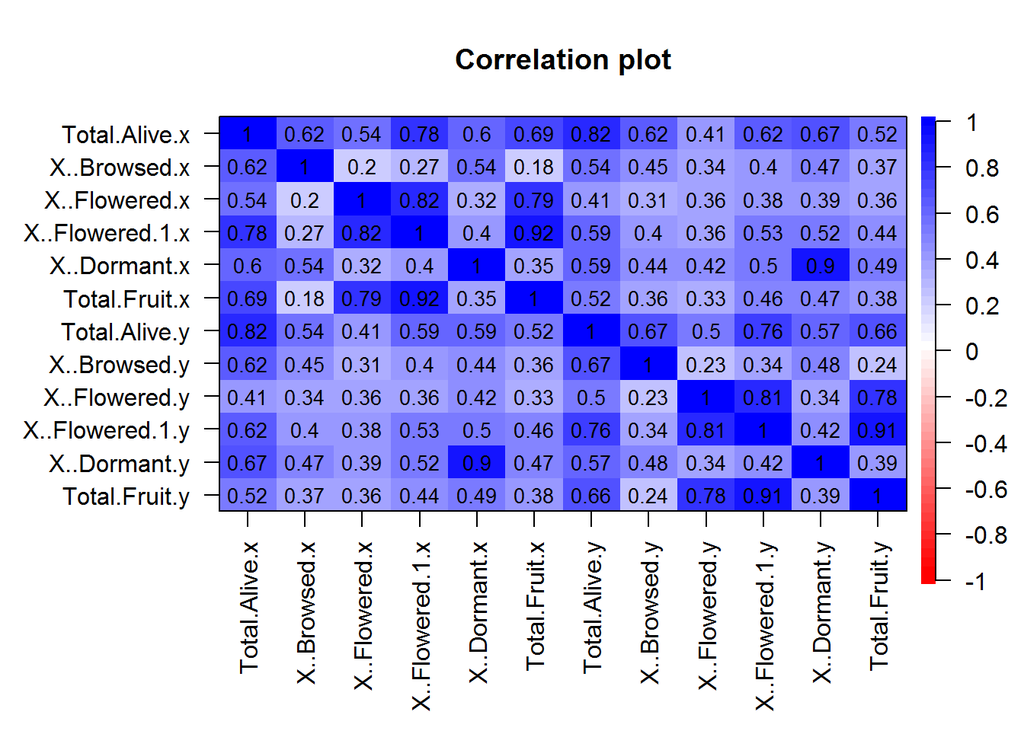

```r
cor.plot(cor(ps.cor[,names(ps.cor) %in%
                      unique(grep(paste(cors,collapse="|"),
                                  names(ps.cor), value=TRUE))]),
         numbers = TRUE)
```

```r
cor(ps.cor[,names(ps.cor) %in%
                      unique(grep(paste(cors,collapse="|"),
                                  names(ps.cor), value=TRUE))])
```

```
##                 Total.Alive.x X..Browsed.x X..Flowered.x X..Flowered.1.x
## Total.Alive.x       1.0000000    0.6189087     0.5443440       0.7814813
## X..Browsed.x        0.6189087    1.0000000     0.1955614       0.2668945
## X..Flowered.x       0.5443440    0.1955614     1.0000000       0.8201308
## X..Flowered.1.x     0.7814813    0.2668945     0.8201308       1.0000000
## X..Dormant.x        0.6031574    0.5392096     0.3195767       0.3976899
## Total.Fruit.x       0.6942636    0.1782428     0.7905942       0.9187185
## Total.Alive.y       0.8210126    0.5419331     0.4071556       0.5877923
## X..Browsed.y        0.6163925    0.4454317     0.3073011       0.4009359
## X..Flowered.y       0.4071813    0.3400942     0.3621557       0.3630998
## X..Flowered.1.y     0.6236757    0.4015587     0.3849140       0.5251684
## X..Dormant.y        0.6670104    0.4746832     0.3923944       0.5212877
## Total.Fruit.y       0.5224584    0.3686650     0.3586403       0.4421705
##                 X..Dormant.x Total.Fruit.x Total.Alive.y X..Browsed.y
## Total.Alive.x      0.6031574     0.6942636     0.8210126    0.6163925
## X..Browsed.x       0.5392096     0.1782428     0.5419331    0.4454317
## X..Flowered.x      0.3195767     0.7905942     0.4071556    0.3073011
## X..Flowered.1.x    0.3976899     0.9187185     0.5877923    0.4009359
## X..Dormant.x       1.0000000     0.3536109     0.5912652    0.4405094
## Total.Fruit.x      0.3536109     1.0000000     0.5180887    0.3613544
## Total.Alive.y      0.5912652     0.5180887     1.0000000    0.6710672
## X..Browsed.y       0.4405094     0.3613544     0.6710672    1.0000000
## X..Flowered.y      0.4170926     0.3283623     0.5002642    0.2288064
## X..Flowered.1.y    0.5046038     0.4553716     0.7604597    0.3357067
## X..Dormant.y       0.8982246     0.4697489     0.5698551    0.4784437
## Total.Fruit.y      0.4903810     0.3824424     0.6601179    0.2410571
##                 X..Flowered.y X..Flowered.1.y X..Dormant.y Total.Fruit.y
## Total.Alive.x       0.4071813       0.6236757    0.6670104     0.5224584
## X..Browsed.x        0.3400942       0.4015587    0.4746832     0.3686650
## X..Flowered.x       0.3621557       0.3849140    0.3923944     0.3586403
## X..Flowered.1.x     0.3630998       0.5251684    0.5212877     0.4421705
## X..Dormant.x        0.4170926       0.5046038    0.8982246     0.4903810
## Total.Fruit.x       0.3283623       0.4553716    0.4697489     0.3824424
## Total.Alive.y       0.5002642       0.7604597    0.5698551     0.6601179
## X..Browsed.y        0.2288064       0.3357067    0.4784437     0.2410571
## X..Flowered.y       1.0000000       0.8113003    0.3371566     0.7785178
## X..Flowered.1.y     0.8113003       1.0000000    0.4200686     0.9076331
## X..Dormant.y        0.3371566       0.4200686    1.0000000     0.3928634
## Total.Fruit.y       0.7785178       0.9076331    0.3928634     1.0000000
```

# If errors:

# dev.off()

```r
dev.off()
```

```r
cors <- c("Total.Alive","X..Browsed","X..Flowered","X..Dormant","Total.Fruit")
write.table(cor(ps.cor[,names(ps.cor) %in%
             unique(grep(paste(cors,collapse="|"),names(ps.cor), value=TRUE))]),
            "clipboard", sep="\t",
            row.names = FALSE, col.names = FALSE)

cor.plot(cor(ps.cor[,names(ps.cor) %in%
                      unique(grep(paste(cors,collapse="|"),
                                  names(ps.cor), value=TRUE))]),
         numbers = TRUE)
```

```r
#x1 is p.value, x2 is correlation
cortests <- lapply(ps.cor[,names(ps.cor) %in%
                            unique(grep(paste(cors,collapse="|"),
                                        names(ps.cor), value=TRUE))],
                   function(x){
                     sapply(ps.cor[,names(ps.cor) %in%
                                     unique(grep(paste(cors,collapse="|"),
                                                 names(ps.cor), value=TRUE))],
                            function(y){
                              ct <- cor.test(x,y)
                              cbind(ct$p.value,ct$estimate)
                              })
                     })


t(cortests[[1]]) # Total.Alive.x to all
```

```
##                          [,1]      [,2]
## Total.Alive.x    0.000000e+00 1.0000000
## X..Browsed.x     7.063212e-68 0.6189087
## X..Flowered.x    6.965677e-50 0.5443440
## X..Flowered.1.x 8.999072e-131 0.7814813
## X..Dormant.x     1.121547e-63 0.6031574
## Total.Fruit.x    9.110970e-92 0.6942636
## Total.Alive.y   5.159429e-155 0.8210126
## X..Browsed.y     3.436049e-67 0.6163925
## X..Flowered.y    1.475666e-26 0.4071813
## X..Flowered.1.y  3.389135e-69 0.6236757
## X..Dormant.y     2.568357e-82 0.6670104
## Total.Fruit.y    2.049731e-45 0.5224584
```

```r
tst <- lapply(cortests, function(x) data.frame(t(x)))
df.c <- do.call(rbind,tst)

cortests[[2]] # X..Browsed.x to all
```

```
##      Total.Alive.x X..Browsed.x X..Flowered.x X..Flowered.1.x X..Dormant.x
## [1,]  7.063212e-68            0  7.550365e-07    9.787087e-12 8.335769e-49
## [2,]  6.189087e-01            1  1.955614e-01    2.668945e-01 5.392096e-01
##      Total.Fruit.x Total.Alive.y X..Browsed.y X..Flowered.y
## [1,]  6.761382e-06  2.246259e-49 4.924816e-32  1.599175e-18
## [2,]  1.782428e-01  5.419331e-01 4.454317e-01  3.400942e-01
##      X..Flowered.1.y X..Dormant.y Total.Fruit.y
## [1,]    8.245948e-26 1.017982e-36  1.025146e-21
## [2,]    4.015587e-01 4.746832e-01  3.686650e-01
```

```r
head(df.c)
```

```
##                                          X1        X2
## Total.Alive.x.Total.Alive.x    0.000000e+00 1.0000000
## Total.Alive.x.X..Browsed.x     7.063212e-68 0.6189087
## Total.Alive.x.X..Flowered.x    6.965677e-50 0.5443440
## Total.Alive.x.X..Flowered.1.x 8.999072e-131 0.7814813
## Total.Alive.x.X..Dormant.x     1.121547e-63 0.6031574
## Total.Alive.x.Total.Fruit.x    9.110970e-92 0.6942636
```

```r
nrow(df.c)
```

```
## [1] 144
```

```r
#significant?
df.c[df.c$X1 < 0.0000001 & df.c$X2 > 0.7 & df.c$X2 < 1,]
```

```
##                                            X1        X2
## Total.Alive.x.X..Flowered.1.x   8.999072e-131 0.7814813
## Total.Alive.x.Total.Alive.y     5.159429e-155 0.8210126
## X..Flowered.x.X..Flowered.1.x   2.075915e-154 0.8201308
## X..Flowered.x.Total.Fruit.x     6.854909e-136 0.7905942
## X..Flowered.1.x.Total.Alive.x   8.999072e-131 0.7814813
## X..Flowered.1.x.X..Flowered.x   2.075915e-154 0.8201308
## X..Flowered.1.x.Total.Fruit.x   1.388289e-255 0.9187185
## X..Dormant.x.X..Dormant.y       2.239658e-226 0.8982246
## Total.Fruit.x.X..Flowered.x     6.854909e-136 0.7905942
## Total.Fruit.x.X..Flowered.1.x   1.388289e-255 0.9187185
## Total.Fruit.x.Total.Fruit.x      0.000000e+00 1.0000000
## Total.Alive.y.Total.Alive.x     5.159429e-155 0.8210126
## Total.Alive.y.X..Flowered.1.y   7.459019e-120 0.7604597
## X..Browsed.y.X..Browsed.y        0.000000e+00 1.0000000
## X..Flowered.y.X..Flowered.y      0.000000e+00 1.0000000
## X..Flowered.y.X..Flowered.1.y   1.564666e-148 0.8113003
## X..Flowered.y.Total.Fruit.y     3.679106e-129 0.7785178
## X..Flowered.1.y.Total.Alive.y   7.459019e-120 0.7604597
## X..Flowered.1.y.X..Flowered.y   1.564666e-148 0.8113003
## X..Flowered.1.y.X..Flowered.1.y  0.000000e+00 1.0000000
## X..Flowered.1.y.Total.Fruit.y   6.198233e-239 0.9076331
## X..Dormant.y.X..Dormant.x       2.239658e-226 0.8982246
## Total.Fruit.y.X..Flowered.y     3.679106e-129 0.7785178
## Total.Fruit.y.X..Flowered.1.y   6.198233e-239 0.9076331
```

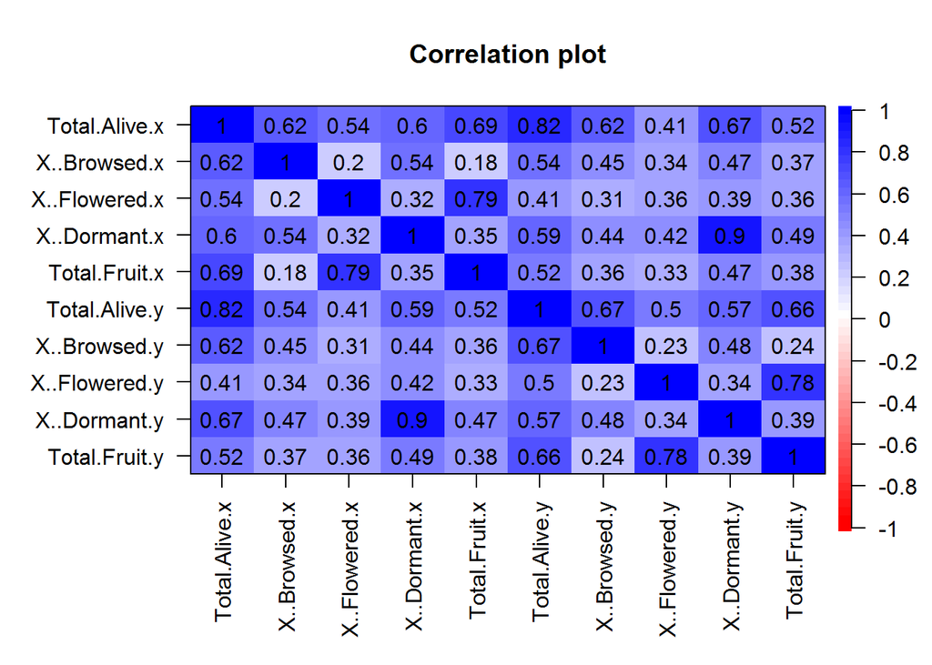

```r
#get rid of the number of reproductive individuals, only percent reproductive
ps.cor <- ps.cor[,grep("Flowered.1.", names(ps.cor), invert=TRUE)]

cors <- c("Total.Alive","X..Browsed","X..Flowered","X..Dormant","Total.Fruit")

cor.plot(cor(ps.cor[,names(ps.cor) %in%
                      unique(grep(paste(cors,collapse="|"),
                                  names(ps.cor), value = TRUE))]),numbers = TRUE)
```

Backwards stepwise multiple linear regressions  
Herbivory  
Browsing is already arcsine aquare root transformed y is the current year x is the previous year

```r
summary(step(lm(Total.Alive.y ~ (X..Browsed.x + X..Browsed.y +
                                   X..Flowered.x + X..Flowered.y)^2,
                data = ps.cor)))
```

```
## Start:  AIC=-178.1
## Total.Alive.y ~ (X..Browsed.x + X..Browsed.y + X..Flowered.x +
##     X..Flowered.y)^2
##
##                               Df Sum of Sq    RSS     AIC
## - X..Browsed.x:X..Flowered.x   1    0.0317 458.60 -180.06
## - X..Flowered.x:X..Flowered.y  1    0.7417 459.31 -179.08
## <none>                                     458.56 -178.10
## - X..Browsed.y:X..Flowered.x   1    2.2769 460.84 -176.98
## - X..Browsed.y:X..Flowered.y   1    2.7164 461.28 -176.38
## - X..Browsed.x:X..Flowered.y   1    2.8816 461.45 -176.15
## - X..Browsed.x:X..Browsed.y    1    4.9815 463.55 -173.29
##
## Step:  AIC=-180.06
## Total.Alive.y ~ X..Browsed.x + X..Browsed.y + X..Flowered.x +
##     X..Flowered.y + X..Browsed.x:X..Browsed.y + X..Browsed.x:X..Flowered.y +
##     X..Browsed.y:X..Flowered.x + X..Browsed.y:X..Flowered.y +
##     X..Flowered.x:X..Flowered.y
##
##                               Df Sum of Sq    RSS     AIC
## - X..Flowered.x:X..Flowered.y  1    0.7893 459.38 -180.97
## <none>                                     458.60 -180.06
## - X..Browsed.y:X..Flowered.x   1    2.2612 460.86 -178.96
## - X..Browsed.y:X..Flowered.y   1    2.8969 461.49 -178.09
## - X..Browsed.x:X..Flowered.y   1    2.9184 461.51 -178.06
## - X..Browsed.x:X..Browsed.y    1    4.9802 463.58 -175.25
##
## Step:  AIC=-180.97
## Total.Alive.y ~ X..Browsed.x + X..Browsed.y + X..Flowered.x +
##     X..Flowered.y + X..Browsed.x:X..Browsed.y + X..Browsed.x:X..Flowered.y +
##     X..Browsed.y:X..Flowered.x + X..Browsed.y:X..Flowered.y
##
##                              Df Sum of Sq    RSS     AIC
## <none>                                    459.38 -180.97
## - X..Browsed.y:X..Flowered.x  1    2.2939 461.68 -179.84
## - X..Browsed.y:X..Flowered.y  1    2.6599 462.04 -179.34
## - X..Browsed.x:X..Flowered.y  1    2.9484 462.33 -178.94
## - X..Browsed.x:X..Browsed.y   1    4.9839 464.37 -176.18
```

```
##
## Call:
## lm(formula = Total.Alive.y ~ X..Browsed.x + X..Browsed.y + X..Flowered.x +
##     X..Flowered.y + X..Browsed.x:X..Browsed.y + X..Browsed.x:X..Flowered.y +
##     X..Browsed.y:X..Flowered.x + X..Browsed.y:X..Flowered.y,
##     data = ps.cor)
##
## Residuals:
##     Min      1Q  Median      3Q     Max
## -2.6680 -0.2165 -0.1421  0.4690  3.0639
##
## Coefficients:
##                             Estimate Std. Error t value Pr(>|t|)
## (Intercept)                  0.14212    0.05446   2.610 0.009281 **
## X..Browsed.x                11.98714    1.78512   6.715 4.25e-11 ***
## X..Browsed.y                22.75632    1.63427  13.924  < 2e-16 ***
## X..Flowered.x                0.98482    0.28921   3.405 0.000704 ***
## X..Flowered.y                2.73045    0.33876   8.060 3.92e-15 ***
## X..Browsed.x:X..Browsed.y  -75.74587   29.18207  -2.596 0.009665 **
## X..Browsed.x:X..Flowered.y  -9.78371    4.90068  -1.996 0.046327 *
## X..Browsed.y:X..Flowered.x  -8.86701    5.03537  -1.761 0.078740 .
## X..Browsed.y:X..Flowered.y -10.29036    5.42675  -1.896 0.058394 .
## ---
## Signif. codes:  0 '***' 0.001 '**' 0.01 '*' 0.05 '.' 0.1 ' ' 1
##
## Residual standard error: 0.8601 on 621 degrees of freedom
## Multiple R-squared:  0.6368, Adjusted R-squared:  0.6321
## F-statistic: 136.1 on 8 and 621 DF,  p-value: < 2.2e-16
```

```r
summary(lm(Total.Alive.y ~ X..Browsed.x, data = ps.cor))
```

```
##
## Call:
## lm(formula = Total.Alive.y ~ X..Browsed.x, data = ps.cor)
##
## Residuals:
##     Min      1Q  Median      3Q     Max
## -2.8696 -0.8109 -0.4577  0.8902  3.3938
##
## Coefficients:
##              Estimate Std. Error t value Pr(>|t|)
## (Intercept)   0.81092    0.06246   12.98   <2e-16 ***
## X..Browsed.x 20.55197    1.27182   16.16   <2e-16 ***
## ---
## Signif. codes:  0 '***' 0.001 '**' 0.01 '*' 0.05 '.' 0.1 ' ' 1
##
## Residual standard error: 1.193 on 628 degrees of freedom
## Multiple R-squared:  0.2937, Adjusted R-squared:  0.2926
## F-statistic: 261.1 on 1 and 628 DF,  p-value: < 2.2e-16
```

```r
summary(lm(Total.Alive.y ~ X..Browsed.y, data = ps.cor))
```

```
##
## Call:
## lm(formula = Total.Alive.y ~ X..Browsed.y, data = ps.cor)
##
## Residuals:
##     Min      1Q  Median      3Q     Max
## -2.4539 -0.5888 -0.5888  0.6539  3.3414
##
## Coefficients:
##              Estimate Std. Error t value Pr(>|t|)
## (Intercept)   0.58883    0.05703   10.32   <2e-16 ***
## X..Browsed.y 25.53941    1.12594   22.68   <2e-16 ***
## ---
## Signif. codes:  0 '***' 0.001 '**' 0.01 '*' 0.05 '.' 0.1 ' ' 1
##
## Residual standard error: 1.052 on 628 degrees of freedom
## Multiple R-squared:  0.4503, Adjusted R-squared:  0.4495
## F-statistic: 514.5 on 1 and 628 DF,  p-value: < 2.2e-16
```

```r
summary(lm(Total.Alive.y ~ X..Flowered.x, data = ps.cor))
```

```
##
## Call:
## lm(formula = Total.Alive.y ~ X..Flowered.x, data = ps.cor)
##
## Residuals:
##     Min      1Q  Median      3Q     Max
## -3.0391 -1.0998 -0.3378  0.9855  3.3310
##
## Coefficients:
##               Estimate Std. Error t value Pr(>|t|)
## (Intercept)    1.09978    0.06116   17.98   <2e-16 ***
## X..Flowered.x  2.79781    0.25045   11.17   <2e-16 ***
## ---
## Signif. codes:  0 '***' 0.001 '**' 0.01 '*' 0.05 '.' 0.1 ' ' 1
##
## Residual standard error: 1.296 on 628 degrees of freedom
## Multiple R-squared:  0.1658, Adjusted R-squared:  0.1644
## F-statistic: 124.8 on 1 and 628 DF,  p-value: < 2.2e-16
```

```r
summary(lm(Total.Alive.y ~ X..Flowered.y, data = ps.cor))
```

```
##
## Call:
## lm(formula = Total.Alive.y ~ X..Flowered.y, data = ps.cor)
##
## Residuals:
##     Min      1Q  Median      3Q     Max
## -2.7483 -1.0173 -0.3241  0.9286  3.4136
##
## Coefficients:
##               Estimate Std. Error t value Pr(>|t|)
## (Intercept)    1.01726    0.05794   17.56   <2e-16 ***
## X..Flowered.y  3.49737    0.24156   14.48   <2e-16 ***
## ---
## Signif. codes:  0 '***' 0.001 '**' 0.01 '*' 0.05 '.' 0.1 ' ' 1
##
## Residual standard error: 1.229 on 628 degrees of freedom
## Multiple R-squared:  0.2503, Adjusted R-squared:  0.2491
## F-statistic: 209.6 on 1 and 628 DF,  p-value: < 2.2e-16
```

```r
sort(unique(ps.cor$Year.x))
```

```
##  [1] 1995 1996 1997 1998 1999 2000 2001 2002 2003 2004 2005 2006 2007 2008
## [15] 2009 2010 2011 2012 2013 2014 2015
```

```r
sort(unique(ps.cor$Year.y))
```

```
##  [1] 1996 1997 1998 1999 2000 2001 2002 2003 2004 2005 2006 2007 2008 2009
## [15] 2010 2011 2012 2013 2014 2015 2016
```

```r
head(ps.asmi.t)
```

```
##   Year Plot Site Total.Plants Total.Alive X..Browsed X..Flowered
## 1 1995    1    1            0           0          0           0
## 2 1995   22    1            0           0          0           0
## 3 1995   32    1            0           0          0           0
## 4 1995   42    1            0           0          0           0
## 5 1995   52    1            0           0          0           0
## 6 1995   16    2            0           0          0           0
##   X..Flowered.1 X..Dormant Total.Fruit Fence
## 1             0          0           0     n
## 2             0          0           0     n
## 3             0          0           0     n
## 4             0          0           0     n
## 5             0          0           0     n
## 6             0          0           0     n
```

```r
t.test(X..Browsed~Fence, data = ps.asmi.t)
```

```
##
##  Welch Two Sample t-test
##
## data:  X..Browsed by Fence
## t = -2.9281, df = 202.73, p-value = 0.0038
## alternative hypothesis: true difference in means is not equal to 0
## 95 percent confidence interval:
##  -0.017506770 -0.003417033
## sample estimates:
## mean in group n mean in group y
##      0.03068867      0.04115057
```

```r
t.test(Total.Fruit.y~Fence.y, data = ps.cor[ps.cor$Year.x > 2005,])
```

```
##
##  Welch Two Sample t-test
##
## data:  Total.Fruit.y by Fence.y
## t = -4.0252, df = 77.356, p-value = 0.0001317
## alternative hypothesis: true difference in means is not equal to 0
## 95 percent confidence interval:
##  -2.4546693 -0.8299168
## sample estimates:
## mean in group n mean in group y
##        1.439343        3.081636
```

```r
t.test(X..Flowered.y~Fence.y, data = ps.cor[ps.cor$Year.x > 2005,])
```

```
##
##  Welch Two Sample t-test
##
## data:  X..Flowered.y by Fence.y
## t = -5.4437, df = 76.206, p-value = 6.122e-07
## alternative hypothesis: true difference in means is not equal to 0
## 95 percent confidence interval:
##  -0.2746529 -0.1275183
## sample estimates:
## mean in group n mean in group y
##       0.1317040       0.3327896
```

```r
t.test(Total.Alive.y~Fence.y, data = ps.cor[ps.cor$Year.x > 2005,])
```

```
##
##  Welch Two Sample t-test
##
## data:  Total.Alive.y by Fence.y
## t = -3.2355, df = 105.02, p-value = 0.001624
## alternative hypothesis: true difference in means is not equal to 0
## 95 percent confidence interval:
##  -0.9911967 -0.2379487
## sample estimates:
## mean in group n mean in group y
##        1.576292        2.190864
```

```r
t.test(X..Browsed.y~Fence.y, data = ps.cor[ps.cor$Year.x > 2005,]) #not signficantly different
```

```
##
##  Welch Two Sample t-test
##
## data:  X..Browsed.y by Fence.y
## t = 0.4961, df = 97.266, p-value = 0.6209
## alternative hypothesis: true difference in means is not equal to 0
## 95 percent confidence interval:
##  -0.007319122  0.012197760
## sample estimates:
## mean in group n mean in group y
##      0.03640547      0.03396615
```

```r
t.test(length~fence, data = asmi.raw[asmi.raw$AsMi_site_id > 2 & asmi.raw$year > 2005,])
```

```
##
##  Welch Two Sample t-test
##
## data:  length by fence
## t = -4.3958, df = 2314.4, p-value = 1.154e-05
## alternative hypothesis: true difference in means is not equal to 0
## 95 percent confidence interval:
##  -4.239302 -1.623748
## sample estimates:
## mean in group n mean in group y
##        8.773488       11.705014
```

Table 3: Average Astragalus microcymbus fruit per plot within the South Beaver Creek Drainage near Gunnison, CO and Cebolla Creek drainage. Site 1 is Cebolla Creek Mid and site 2 is Cebolla Creek North. Standard errors are given in parentheses.

```r
fruit <- aggregate(fruit ~ AsMi_plot_id + year + AsMi_site_id + fence,
                  data = asmi.raw, function(x) sum(x,na.rm = TRUE))
head(fruit)
```

```
##   AsMi_plot_id year AsMi_site_id fence fruit
## 1            1 2014            1     n     6
## 2           22 2014            1     n     0
## 3           32 2014            1     n     8
## 4           42 2014            1     n    12
## 5           52 2014            1     n     1
## 6            1 2015            1     n     0
```

```r
tbl3.1 <- summarySE(fruit, measurevar="fruit",groupvars=c("AsMi_site_id","year"))

sites <- unique(tbl3.1$AsMi_site_id)
tbl3 <- lapply(sites, function(x){
  paste(round(tbl3.1[tbl3.1$AsMi_site_id == x,"fruit"],2)," (",
        round(tbl3.1[tbl3.1$AsMi_site_id == x,"se"],1), ")", sep="")
})

#Cebolla Creek
data.frame(tbl3[[1]],tbl3[[2]])
```

```
##     tbl3..1..    tbl3..2..
## 1   5.4 (2.2) 25.33 (20.2)
## 2   3.4 (2.1)     12 (7.2)
## 3 30.2 (13.9)   16.5 (5.8)
```

```r
#South Beaver Creek
data.frame(tbl3[[3]],tbl3[[4]],tbl3[[5]],tbl3[[6]])
```

```
##        tbl3..3..        tbl3..4..       tbl3..5..       tbl3..6..
## 1  305.4 (103.8) 2034.25 (1248.6) 1143.25 (256.1)  859.33 (287.4)
## 2          0 (0)          2 (1.7)         5.2 (5)         2 (1.4)
## 3    85.4 (46.5)    2292 (1507.9)     894 (498.4) 1654.25 (403.1)
## 4          0 (0)          3 (1.3)           0 (0)         1.5 (1)
## 5          0 (0)   245.67 (160.7)    232.8 (97.9)      100 (40.8)
## 6          0 (0)            0 (0)      13.8 (7.2)         3 (1.8)
## 7      3.6 (1.6)       1.75 (1.8)     17.6 (14.4)      1.25 (1.2)
## 8          0 (0)            0 (0)           0 (0)           0 (0)
## 9      4.2 (3.3)        18 (10.4)     36.4 (12.9)     39.5 (39.5)
## 10         0 (0)            0 (0)     48.6 (35.3)     15.8 (14.8)
## 11         0 (0)       1.25 (1.2)       21 (14.8)       8.8 (7.6)
## 12     3.8 (3.6)     33.75 (23.8)   250.4 (168.3)        119 (73)
## 13         0 (0)       0.25 (0.2)     33.6 (26.7)       1.4 (0.7)
## 14     5.8 (5.8)   383.25 (269.5) 5030.8 (2830.4)  1394.8 (409.2)
## 15     7.6 (7.1)      555 (418.7)  1175.8 (560.3)  2095.8 (670.5)
## 16       1.4 (1)        67 (28.7)        204 (75)   586.8 (137.1)
## 17       2 (1.3)      391 (214.1)   217.4 (134.7)   351.4 (170.2)
## 18         0 (0)            0 (0)           0 (0)           0 (0)
## 19     0.2 (0.2)            0 (0)         6 (5.8)           0 (0)
## 20       7 (4.4)     20.33 (14.3)       59 (27.5)           0 (0)
## 21  15.75 (12.6)        299 (125)     151 (145.8)    144.4 (94.8)
## 22     7.5 (4.9)   281.33 (162.1)     31.4 (10.8)       5.2 (5.2)
```

```r
table(asmi.raw$browsing)
```

```
##
##     0     1
## 11122  2684
```

```r
table(asmi.raw$Browsing...Status)
```

```
##
##            Insect            Mammal Mammal and Insect              None
##               457              1005                77             10878
##     Yes - Unknown
##              1145
```

```r
nrow(asmi.raw) #13806
```

```
## [1] 13806
```

```r
table(asmi.raw$AsMi_site_id,asmi.raw$year)
```

```
##
##      1995 1996 1997 1998 1999 2000 2001 2002 2003 2004 2005 2006 2007 2008
##   1     0    0    0    0    0    0    0    0    0    0    0    0    0    0
##   2     0    0    0    0    0    0    0    0    0    0    0    0    0    0
##   5    96   96   68   71   61   57   58   55   42   43   38   42   47   45
##   15  185  195  202  185  150  139  117   99   95  108  110  124  124  132
##   19  177  194  231  213  159  163  170  150  125  163  170  178  173  170
##   26  336  399  304  261  207  191  174  143  120  155  157  167  174  194
##
##      2009 2010 2011 2012 2013 2014 2015 2016
##   1     0    0    0    0    0  128  392  357
##   2     0    0    0    0    0   89  319  390
##   5    50   51   38   22   15   15   18   17
##   15  149  148  135  111   59   74  120  131
##   19  192  184  169  127   65  117  189  245
##   26  275  274  240  191   68   73  166  201
```

```r
cebolla <- asmi.raw[asmi.raw$AsMi_site_id %in% c(1,2),]
table(cebolla$AsMi_site_id,cebolla$year)
```

```
##
##     2014 2015 2016
##   1  128  392  357
##   2   89  319  390
```

```r
sbc <- asmi.raw[asmi.raw$AsMi_site_id %in% c(5,15,19,26),]
table(sbc$AsMi_site_id,sbc$year)
```

```
##
##      1995 1996 1997 1998 1999 2000 2001 2002 2003 2004 2005 2006 2007 2008
##   5    96   96   68   71   61   57   58   55   42   43   38   42   47   45
##   15  185  195  202  185  150  139  117   99   95  108  110  124  124  132
##   19  177  194  231  213  159  163  170  150  125  163  170  178  173  170
##   26  336  399  304  261  207  191  174  143  120  155  157  167  174  194
##
##      2009 2010 2011 2012 2013 2014 2015 2016
##   5    50   51   38   22   15   15   18   17
##   15  149  148  135  111   59   74  120  131
##   19  192  184  169  127   65  117  189  245
##   26  275  274  240  191   68   73  166  201
```

```r
#remove plot 598 from SBC, it was added so late.. or do all plots on their own instead of by sites?
#sbc <- sbc[sbc$AsMi_plot_id != 598,]

# the others added later: 238 & 300 @ 1996 - take out 1995
#sbc <- sbc[sbc$year > 1995,]

asmi.1 <- sbc[order(sbc$AsMi_site_id, sbc$AsMi_tag_id, sbc$year),]
cebolla <- cebolla[order(cebolla$AsMi_site_id, cebolla$AsMi_tag_id, cebolla$year),]

asmi.1$status <- factor(asmi.1$status)
table(asmi.1$status)
```

```
##
##         dead      dormant reproductive     seedling   vegetative
##         1885         4320         1966         1378         2582
```

```r
cebolla$status <- factor(cebolla$status)
table(cebolla$status)
```

```
##
##         dead      dormant reproductive     seedling   vegetative
##          352           17           80          855          371
```

Set order of classes

```r
# Later work in seeds
# stages <- c("seed", "seedling", "vegetative", "reproductive", "dormant","dead")

stages <- c("seedling", "vegetative", "reproductive", "dormant","dead")

asmi.1$status <- ordered(asmi.1$status, levels = stages)
cebolla$status <- ordered(cebolla$status, levels = stages)
```

check errors

```r
table(asmi.1$status)
```

```
##
##     seedling   vegetative reproductive      dormant         dead
##         1378         2582         1966         4320         1885
```

```r
table(cebolla$status)
```

```
##
##     seedling   vegetative reproductive      dormant         dead
##          855          371           80           17          352
```

```r
asmi.1[asmi.1$flower == 1 & asmi.1$status == "vegetative",]
```

```
##  [1] AsMi_data_id      AsMi_tag_id       year
##  [4] length            flower            fruit
##  [7] browsing          Browsing...Status status
## [10] comments          tag_no            AsMi_plot_id
## [13] AsMi_site_id      fence             plotlocation
## [16] location          direction         direction.1
## [19] distance          invalid_tag
## <0 rows> (or 0-length row.names)
```

```r
cebolla[cebolla$flower == 1 & cebolla$status == "vegetative",]
```

```
##  [1] AsMi_data_id      AsMi_tag_id       year
##  [4] length            flower            fruit
##  [7] browsing          Browsing...Status status
## [10] comments          tag_no            AsMi_plot_id
## [13] AsMi_site_id      fence             plotlocation
## [16] location          direction         direction.1
## [19] distance          invalid_tag
## <0 rows> (or 0-length row.names)
```

```r
table(asmi.1$year,asmi.1$status)
```

```
##
##        seedling vegetative reproductive dormant dead
##   1995        0        388          406       0    0
##   1996       21        288           55     218  302
##   1997      217        106          212     170  100
##   1998       25        253           20     268  164
##   1999       11        163          103     243   57
##   2000       27        163           16     257   87
##   2001       56         87           28     271   77
##   2002        3         58            0     303   83
##   2003       18         27           25     296   16
##   2004       76         61           39     275   18
##   2005       24         76           17     307   51
##   2006       88         99           54     242   28
##   2007       34        104           54     282   44
##   2008       67         76          171     201   26
##   2009      153         71          199     186   57
##   2010       47         94          251     163  102
##   2011       27        137          179     108  131
##   2012        0         18            0     182  251
##   2013        4         31            6     155   11
##   2014       83         46           25     110   15
##   2015      229         63           51      83   67
##   2016      168        173           55       0  198
```

```r
table(asmi.1$year, asmi.1$AsMi_site_id)
```

```
##
##          5  15  19  26
##   1995  96 185 177 336
##   1996  96 195 194 399
##   1997  68 202 231 304
##   1998  71 185 213 261
##   1999  61 150 159 207
##   2000  57 139 163 191
##   2001  58 117 170 174
##   2002  55  99 150 143
##   2003  42  95 125 120
##   2004  43 108 163 155
##   2005  38 110 170 157
##   2006  42 124 178 167
##   2007  47 124 173 174
##   2008  45 132 170 194
##   2009  50 149 192 275
##   2010  51 148 184 274
##   2011  38 135 169 240
##   2012  22 111 127 191
##   2013  15  59  65  68
##   2014  15  74 117  73
##   2015  18 120 189 166
##   2016  17 131 245 201
```

```r
table(asmi.1$length)
```

```
##
##     0   0.3   0.5   0.7     1   1.5   1.8     2   2.2   2.3   2.5     3
##  5976     3     4     1    37    24     1   181     1     2    38   284
##   3.2   3.4   3.5   3.6   3.7  3.75     4   4.2  4.25   4.5   4.7   4.8
##     1     3    41     1     3     2   321     1     1    49     1     1
##     5  5.25  5.47   5.5   5.7   5.8     6   6.2  6.25   6.3   6.4   6.5
##   300     1     1    38     1     1   297     1     1     1     2    49
##   6.6   6.7  6.75   6.8     7   7.1  7.25   7.4   7.5     8   8.3   8.5
##     1     2     1     1   264     1     1     1    29   205     2    20
##  8.75     9  9.25   9.4   9.5   9.6   9.7   9.8    10  10.2  10.4  10.5
##     1   202     1     1     8     1     2     1   196     1     1    27
##  10.6    11  11.2 11.25  11.3  11.5    12  12.2  12.4  12.5  12.7    13
##     1   137     1     1     1    10   177     2     1     9     1   138
##  13.3  13.4  13.5  13.7    14  14.5  14.7    15  15.3  15.5  15.6  15.8
##     1     1    12     1   124    10     2   100     1     6     2     1
```

[output cut: 22 more lines]

```r
table(cebolla$length)
```

```
##
##    0  0.5    1  1.5    2  2.5    3  3.5    4  4.5    5  5.5    6  6.5    7
##  369    5   25    8   51   12   96    9  125   15  114   16  109    9   73
##  7.5    8  8.5    9  9.5   10 10.5   11 11.5   12 12.5   13 13.5   14   15
##    8   70    9   61    5   60    4   36    1   30    3   28    2   30   23
## 15.5   16 16.5   17 17.5   18 18.5   19   20 20.5   21 21.5   22 22.5   23
##    1   21    3   32    1    4    1   18   20    1   13    2   15    1   13
##   24   25 25.5   26 26.5   27   28 28.5   29 29.5   30   31   32   33   34
##   11   12    2    6    2    7    9    2    2    1   11    6    7    2    5
##   35   36   37   38   39   40   41 41.5   42   43   45   47   48   49   51
##    6    4    3    4    3    2    1    1    1    3    1    3    1    1    1
##   52   57   64
##    1    1    1
```

```r
cebolla[cebolla$flower == 1 & cebolla$status == "vegetative",]
```

```
##  [1] AsMi_data_id      AsMi_tag_id       year
##  [4] length            flower            fruit
##  [7] browsing          Browsing...Status status
## [10] comments          tag_no            AsMi_plot_id
## [13] AsMi_site_id      fence             plotlocation
## [16] location          direction         direction.1
## [19] distance          invalid_tag
## <0 rows> (or 0-length row.names)
```

```r
asmi.1[is.na(asmi.1$length),]
```

```
##       AsMi_data_id AsMi_tag_id year length flower fruit browsing
## 1750         10330          10 2006     NA      0    NA        0
## 2626         10603          24 1999     NA      0    NA        0
## 1945         11014          36 2004     NA      0    NA        0
## 1946         11015          36 2005     NA      0    NA        0
## 1947         11016          36 2006     NA      0    NA        0
## 2013         11706          42 1996     NA      0    NA        0
## 2014         11707          42 1997     NA      0    NA        0
## 2015         11708          42 1998     NA      0    NA        0
## 2022         11715          42 2005     NA      0    NA        0
## 2023         11716          42 2006     NA      0    NA        0
## 2024         11717          42 2007     NA      0    NA        0
## 2025         11718          42 2008     NA      0    NA        0
## 2005         11673          43 2005     NA      0    NA        0
## 2011         26282          43 2011     NA      0    NA        0
```

[output cut: 1260 more lines]

```r
asmi.1[asmi.1$length > 100 & !is.na(asmi.1$length),]
```

```
##       AsMi_data_id AsMi_tag_id year length flower fruit browsing
## 10078        20650        1510 2008    921      1     0        1
##       Browsing...Status       status                    comments tag_no
## 10078            Mammal reproductive mammal (most stems browsed)    925
##       AsMi_plot_id AsMi_site_id fence plotlocation
## 10078          238           26     y         <NA>
##                                  location direction direction.1 distance
## 10078 tag S 5cm in sagebrush, young dense        SE         135      1.9
##       invalid_tag
## 10078       FALSE
```

```r
# One length that was recorded crazy
asmi.1$length[asmi.1$length == 921] <- NA

asmi.1$browsed[asmi.1$browsing==0]<-FALSE
asmi.1$browsed[asmi.1$browsing==1]<-TRUE
table(asmi.1$browsed)
```

```
##
## FALSE  TRUE
## 10005  2126
```

```r
table(asmi.1$browsing)
```

```
##
##     0     1
## 10005  2126
```

```r
# Same for cebolla plots
cebolla$browsed[cebolla$browsing==0]<-FALSE
cebolla$browsed[cebolla$browsing==1]<-TRUE
table(cebolla$browsed)
```

```
##
## FALSE  TRUE
##  1117   558
```

```r
table(cebolla$browsing)
```

```
##
##    0    1
## 1117  558
```

Merge year to year, year.x is year t, year.y is year t+1  
remove dead from stages, just fate

```r
asmi.2 <- subset(merge(asmi.1, asmi.1, by = "AsMi_tag_id", sort = FALSE), year.x == year.y - 1)
cebolla <- subset(merge(cebolla, cebolla, by = "AsMi_tag_id", sort = FALSE), year.x == year.y - 1)
names(asmi.2)
```

```
##  [1] "AsMi_tag_id"         "AsMi_data_id.x"      "year.x"
##  [4] "length.x"            "flower.x"            "fruit.x"
##  [7] "browsing.x"          "Browsing...Status.x" "status.x"
## [10] "comments.x"          "tag_no.x"            "AsMi_plot_id.x"
## [13] "AsMi_site_id.x"      "fence.x"             "plotlocation.x"
## [16] "location.x"          "direction.x"         "direction.1.x"
## [19] "distance.x"          "invalid_tag.x"       "browsed.x"
## [22] "AsMi_data_id.y"      "year.y"              "length.y"
## [25] "flower.y"            "fruit.y"             "browsing.y"
## [28] "Browsing...Status.y" "status.y"            "comments.y"
## [31] "tag_no.y"            "AsMi_plot_id.y"      "AsMi_site_id.y"
## [34] "fence.y"             "plotlocation.y"      "location.y"
## [37] "direction.y"         "direction.1.y"       "distance.y"
## [40] "invalid_tag.y"       "browsed.y"
```

```r
names(cebolla)
```

```
##  [1] "AsMi_tag_id"         "AsMi_data_id.x"      "year.x"
##  [4] "length.x"            "flower.x"            "fruit.x"
##  [7] "browsing.x"          "Browsing...Status.x" "status.x"
## [10] "comments.x"          "tag_no.x"            "AsMi_plot_id.x"
## [13] "AsMi_site_id.x"      "fence.x"             "plotlocation.x"
## [16] "location.x"          "direction.x"         "direction.1.x"
## [19] "distance.x"          "invalid_tag.x"       "browsed.x"
## [22] "AsMi_data_id.y"      "year.y"              "length.y"
## [25] "flower.y"            "fruit.y"             "browsing.y"
## [28] "Browsing...Status.y" "status.y"            "comments.y"
## [31] "tag_no.y"            "AsMi_plot_id.y"      "AsMi_site_id.y"
## [34] "fence.y"             "plotlocation.y"      "location.y"
## [37] "direction.y"         "direction.1.y"       "distance.y"
## [40] "invalid_tag.y"       "browsed.y"
```

Want  
Narrow down to  
[1] “AsMi_site_id.x” “AsMi_tag_id” “year.x”  
[4] “length.x” “fruit.x” “browsed.x”  
[7] “fence.x” “status.x” “status.y”

```r
cols <- c("AsMi_site_id.x","AsMi_tag_id","year.x","length.x",
          "fruit.x","browsed.x","fence.x","status.x","status.y","AsMi_plot_id.x")
asmi.2 <- asmi.2[, names(asmi.2) %in% unique(grep(paste(cols,collapse="|"),
                                                  names(asmi.2), value = TRUE))]
colnames(asmi.2) <- c( "tag","year","length","fruits","stage","plot",
                       "site","fenced","browse","fate")
## re-number
rownames(asmi.2) <- 1:nrow(asmi.2)
# Get rid of stage 'dead'
asmi.2$stage <- ordered(asmi.2$stage, levels = stages[-length(stages)])
# check transitions
#fate down and stage across the top; These are the raw numbers combined for all years
table(Fate = asmi.2$fate, Stage = asmi.2$stage)
```

```
##               Stage
## Fate           seedling vegetative reproductive dormant
##   seedling            0          0            0       0
##   vegetative        380        631          536     562
##   reproductive      193        439          634     273
##   dormant           176        404          256    3480
##   dead              459        934          485       0
```

```r
table(asmi.2$site, asmi.2$year)
```

```
##
##      1995 1996 1997 1998 1999 2000 2001 2002 2003 2004 2005 2006 2007 2008
##   5    96   53   62   59   54   48   55   41   35   38   27   42   43   39
##   15  185  145  177  146  137  111   99   94   92  108  106  119  112  126
##   19  177  124  208  157  141  147  146  114  123  155  154  164  159  160
##   26  336  260  258  204  188  155  142  115  116  150  136  158  160  188
##
##      2009 2010 2011 2012 2013 2014 2015
##   5    48   36   22   14   14   13   14
##   15  133  128  111   58   58   72  109
##   19  173  154  127   62   60  117  154
##   26  254  236  191   66   64   62  148
```

```r
table(asmi.2$plot, asmi.2$year)
```

```
##
##       1995 1996 1997 1998 1999 2000 2001 2002 2003 2004 2005 2006 2007
##   8    103   82   75   60   58   51   46   44   44   49   49   60   59
##   238    0   55   46   39   36   24   25   20   20   22   21   28   31
##   300    0   12   57   42   37   42   42   36   44   56   53   60   56
##   480   84   49   53   41   39   30   25   18   18   18   18   24   29
##   512   39   25   40   28   24   28   27   22   23   29   24   29   30
##   513   28   13   14   14   11   11   14   10   10   15   16   15   15
##   514   37   29   45   29   28   25   23   17   17   26   32   30   24
##   515   73   45   52   44   41   41   40   29   29   29   29   30   34
##   578   18   11   18   12   12   12   15   14   14   18   16   16   16
##   581    1    1    2    2    2    2    1    1    1    1    2    1    0
##   598    0    0    0    0    0    0    0    0    0   26   21   26   23
##   606   12    7    9    7    8    7    9    5    6    5    3    4    4
##   607   38   17   24   22   18   18   25   22   17   20   14   23   22
```

[output cut: 27 more lines]

```r
table(asmi.2$stage)
```

```
##
##     seedling   vegetative reproductive      dormant
##         1208         2408         1911         4315
```

```r
cebolla.2 <- cebolla[, names(cebolla) %in% unique(grep(paste(cols,collapse="|"),
                                                  names(cebolla), value = TRUE))]
colnames(cebolla.2) <- c( "tag","year","length","fruits","stage","plot",
                       "site","fenced","browse","fate")
```

bootstrap distributions of population growth rates (lambda), stage vectors, and projection matrix elements by randomly sampling with replacement from a stage-fate data frame of observed transitions

Doesn’t make sense… shouldn’t be so high… Because 26 had additional plots added in 1996?

```r
boottrans <- lapply(unique(asmi.2$site), function(x){
  data.frame(cbind(Site = x,
                   Boot = boot.transitions(asmi.2[asmi.2$site == x & asmi.2$fenced == "n",],
                                           1000,
                                           fertility = "fruits")$lambda))
  })

bt <- do.call(rbind, boottrans)
head(bt)
```

```
##   Site     Boot
## 1    5 1.390841
## 2    5 1.146003
## 3    5 1.338670
## 4    5 1.600600
## 5    5 1.616741
## 6    5 1.610071
```

```r
dev.off()
```

```r
ggplot(bt, aes(as.factor(Site), Boot, colour = as.factor(Site)))+
  geom_boxplot()
```

# Figure 2b

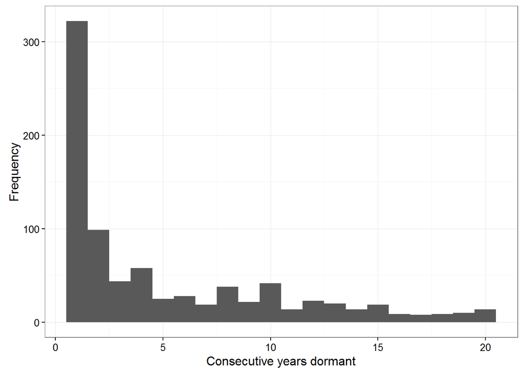

```r
dorms <- rle(as.numeric(asmi.2$stage))$lengths[rle(as.numeric(asmi.2$stage))$values ==4]

ggplot(data.frame(Dormant = dorms), aes(Dormant))+
  geom_histogram(bins = 20)+
  theme_bw()+
  ylab("Frequency")+
  xlab("Consecutive years dormant")
```

# only South beaver creek

```r
median(dorms) #3
```

```
## [1] 2
```

```r
length(dorms[dorms==1]) #305
```

```
## [1] 322
```

```r
length(dorms[dorms==1])/length(dorms) # 37.7%
```

```
## [1] 0.3847073
```

```r
length(dorms) #808
```

```
## [1] 837
```

```r
length(dorms[dorms > 5]) #286
```

```
## [1] 289
```

```r
length(dorms[dorms > 15]) #50
```

```
## [1] 50
```

```r
length(dorms[dorms == 18]) #9
```

```
## [1] 9
```

Reproductive lengths

```r
repros <- rle(as.numeric(asmi.2$stage))$lengths[rle(as.numeric(asmi.2$stage))$values ==3]
max(repros)
```

```
## [1] 8
```

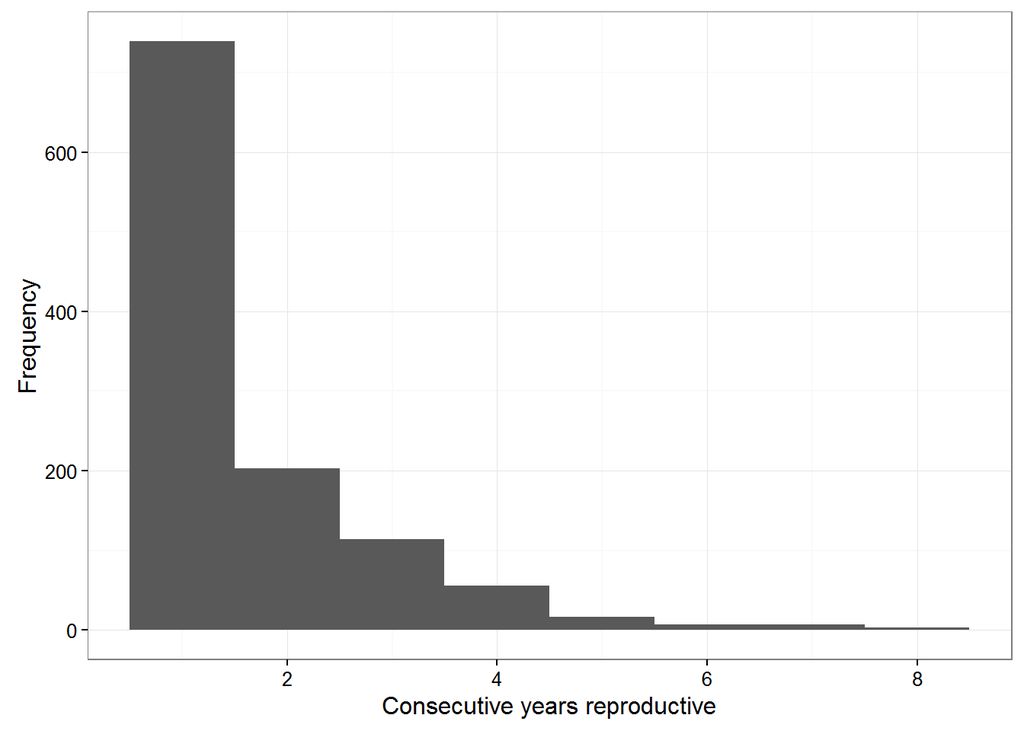

```r
ggplot(data.frame(Repro = repros), aes(Repro))+
  geom_histogram(bins=8)+
  theme_bw()+
  ylab("Frequency")+
  xlab("Consecutive years reproductive")
```

Dormancy can be set to 0-1

```r
asmi.pva <- StagePVA(asmi.2)
cebolla.pva <- StagePVA(cebolla.2)
```

By plot, South Beaver Creek

```r
site <- sapply(unique(asmi.2$site), function(x){
  as.character(unique(asmi.2$plot[asmi.2$site == x]))
  }, simplify = FALSE)
names(site)<-unique(asmi.2$site)
site
```

```
## $`5`
## [1] "607" "608" "606" "610" "609"
##
## $`15`
## [1] "799" "581" "578" "8"
##
## $`19`
## [1] "512" "513" "514" "515" "300"
##
## $`26`
## [1] "611" "614" "480" "238" "598"
```

```r
asmi.pva$plot.matrix[site$'15'[1]]
```

```
## $`799`
## $`799`$`1995`
##
##                   seedling  vegetative reproductive     dormant
##   seedling     0.036077669 0.000000000  0.291551247 0.000000000
##   vegetative   0.326923077 0.250000000  0.666666667 0.928571429
##   reproductive 0.009615385 0.000000000  0.000000000 0.071428571
##   dormant      0.000000000 0.000000000  0.000000000 0.000000000
##
## $`799`$`1996`
##
##                   seedling  vegetative reproductive     dormant
##   seedling     0.172371085 0.000000000  1.392967067 0.000000000
##   vegetative   0.326923077 0.250000000  0.666666667 0.928571429
##   reproductive 0.009615385 0.000000000  0.000000000 0.071428571
##   dormant      0.000000000 0.000000000  0.000000000 0.733333333
##
## $`799`$`1997`
##
##                   seedling  vegetative reproductive     dormant
##   seedling     0.024051779 0.000000000  0.194367498 0.000000000
##   vegetative   0.326923077 0.250000000  0.666666667 0.928571429
##   reproductive 0.009615385 0.000000000  0.000000000 0.071428571
##   dormant      0.000000000 0.000000000  0.000000000 0.937500000
##
## $`799`$`1998`
##
##                   seedling  vegetative reproductive     dormant
##   seedling     0.012025890 0.000000000  0.097183749 0.000000000
##   vegetative   0.326923077 0.250000000  0.666666667 0.928571429
##   reproductive 0.009615385 0.000000000  0.000000000 0.071428571
##   dormant      0.000000000 0.000000000  0.000000000 0.958333333
##
## $`799`$`1999`
##
##                   seedling  vegetative reproductive     dormant
##   seedling     0.008017260 0.000000000  0.064789166 0.000000000
##   vegetative   0.326923077 0.250000000  0.666666667 0.928571429
##   reproductive 0.009615385 0.000000000  0.000000000 0.071428571
##   dormant      0.000000000 0.000000000  0.000000000 0.793103448
```

[output cut: 113 more lines]

```
## $`799`$`2014`
##
##                   seedling  vegetative reproductive     dormant
##   seedling     0.064138078 0.000000000  0.518313327 0.000000000
##   vegetative   0.326923077 0.250000000  0.666666667 0.928571429
##   reproductive 0.009615385 0.000000000  0.000000000 0.071428571
##   dormant      0.000000000 0.000000000  0.000000000 0.666666667
##
## $`799`$`2015`
##
##                   seedling  vegetative reproductive     dormant
##   seedling     0.000000000 0.000000000  0.000000000 0.000000000
##   vegetative   0.326923077 0.250000000  0.666666667 0.928571429
##   reproductive 0.009615385 0.000000000  0.000000000 0.071428571
##   dormant      0.000000000 0.000000000  0.000000000 0.000000000
```

# Table 4: Growth rate

All

```r
lmdSD(asmi.pva$pro.matrix, 1996, currentyr-2)
```

```
##          lmda        SD
## [1,] 1.191408 0.9915946
```

```r
#         lmda        SD
# [1,] 1.179791 0.9690063
paste(round(lmdSD(asmi.pva$pro.matrix, 1996, 2004)[1],2)," (",
      round(lmdSD(asmi.pva$pro.matrix, 1996, 2004)[2],2), ")", sep ="")
```

```
## [1] "1 (0.33)"
```

```r
mats.list <- list(asmi.pva$pro.matrix,asmi.pva$fenced.pro.matrix,asmi.pva$notfenced.pro.matrix)
tbl4.all <- sapply(mats.list, function(x){
   paste(round(lmdSD(x, 1996, 2004)[1],2)," (",
         round(lmdSD(x, 1996, 2004)[2],2),")", sep="")
    })

tbl4.allpost <- sapply(mats.list[-1], function(x){
  paste(round(lmdSD(x, 2005,currentyr-2)[1],2)," (",
        round(lmdSD(x, 2005,currentyr-2)[2],2),")", sep="")
})

tbl4.allopen <- paste(round(lmdSD(asmi.pva$notfenced.pro.matrix, 1996,currentyr-2)[1],2)," (",
                      round(lmdSD(asmi.pva$notfenced.pro.matrix, 1996,currentyr-2)[2],2),")", sep="")
```

Cebolla all 1:Mid 2:North

```r
lmdSD(cebolla.pva$pro.matrix, 2014, currentyr-2)
```

```
##          lmda SD
## [1,] 2.277778 NA
```

```r
# lmdSD(cebolla.pva$pro.matrix, 2014, currentyr-1) #in 2016, not enough data to exclude the last one
#         lmda       SD
#[1,] 1.138889 1.038878
paste(round(lmdSD(cebolla.pva$Site$`1`, 2014, currentyr-1)[1],2)," (",
      round(lmdSD(cebolla.pva$Site$`1`, 2014, currentyr-1)[2],2), ")", sep ="")
```

```
## [1] "1.04 (0.76)"
```

```r
paste(round(lmdSD(cebolla.pva$Site$`2`, 2014, currentyr-1)[1],2)," (",
      round(lmdSD(cebolla.pva$Site$`2`, 2014, currentyr-1)[2],2), ")", sep ="")
```

```
## [1] "1.28 (1.24)"
```

```r
mats.list <- list(cebolla.pva$pro.matrix,cebolla.pva$fenced.pro.matrix,cebolla.pva$notfenced.pro.matrix)
sapply(mats.list, function(x){
   paste(round(lmdSD(x, 2014, currentyr-2)[1],2)," (",
         round(lmdSD(x, 2014, currentyr-2)[2],2),")", sep="")
    })
```

```
## [1] "2.28 (NA)" "0 (NA)"    "2.28 (NA)"
```

T-test fenced vs. open after fencing installed

```r
t.test(lmdAn(asmi.pva$fenced.pro.matrix, 2005, currentyr-2),
       lmdAn(asmi.pva$notfenced.pro.matrix, 2005, currentyr-2),
       paired = TRUE)
```

```
##
##  Paired t-test
##
## data:  lmdAn(asmi.pva$fenced.pro.matrix, 2005, currentyr - 2) and lmdAn(asmi.pva$notfenced.pro.matrix, 2005, currentyr - 2)
## t = 1.0255, df = 9, p-value = 0.3319
## alternative hypothesis: true difference in means is not equal to 0
## 95 percent confidence interval:
##  -0.6073508  1.6146974
## sample estimates:
## mean of the differences
##               0.5036733
```

# Table 4

pattern is:

Sites 5,19,26, 1996-2004  
(which is through 2005 but starting transition of 2004)

| 1996-2005 | 2005-2014 | 1996-2014 |
| --- | --- | --- |
| asmi.pva$Site$“5” |  |  |
| asmi.pva$fenced$“5” | asmi.pva$fenced$“5” |  |
| asmi.pva$notfenced$“5” | asmi.pva$notfenced$“5” | asmi.pva$notfenced$“5” |

Site 15 `asmi.pva$Site$"15"` …

[[1]]:All; [[2]]:fenced; [[3]]:open

```r
matord.list <- list(asmi.pva$Site, asmi.pva$fenced,asmi.pva$notfenced)

lapply(seq_along(asmi.pva$Site), function(n,i){ paste(n[[i]])},
       n=names(asmi.pva$Site))
```

```
## [[1]]
## [1] ""
##
## [[2]]
## [1] ""
##
## [[3]]
## [1] ""
##
## [[4]]
## [1] ""
##
## [[5]]
## [1] ""
##
## [[6]]
## [1] ""
##
## [[7]]
## [1] ""
##
## [[8]]
## [1] ""
##
## [[9]]
## [1] ""
##
## [[10]]
## [1] ""
##
## [[11]]
## [1] ""
##
## [[12]]
## [1] ""
##
## [[13]]
## [1] ""
##
## [[14]]
```

[output cut: 19 more lines]

```
##
## [[21]]
## [1] ""
##
## [[22]]
## [1] "5"
##
## [[23]]
## [1] "15"
##
## [[24]]
## [1] "19"
##
## [[25]]
## [1] "26"
```

```r
# 1996 (remove first year) through 2004 since it's 2004-2005 before fencing
# All
# not working! move on to one by one
tbl4.96.04 <-
  lapply(as.character(unique(asmi.2$site)), function(x){
    mat <- cat("matord.list[[1]]$\`",x,"`", sep='')
    lapply(mat, function(y){
      paste(round(lmdSD(y[[factor(x)]],1996,2004)[1],2)," (",
            round(lmdSD(y[[factor(x)]],1996,2004)[2],2),")", sep="")
    })
  })
```

```
## matord.list[[1]]$`5`matord.list[[1]]$`15`matord.list[[1]]$`19`matord.list[[1]]$`26`
```

```r
#site 5
paste(round(lmdSD(asmi.pva$Site$'5',1996,2004)[1],2)," (",
            round(lmdSD(asmi.pva$Site$'5',1996,2004)[2],2),")", sep="")
```

```
## [1] "0.89 (0.12)"
```

```r
paste(round(lmdSD(asmi.pva$fenced$'5',1996,2004)[1],2)," (",
            round(lmdSD(asmi.pva$fenced$'5',1996,2004)[2],2),")", sep="")
```

```
## [1] "0.91 (0.14)"
```

```r
paste(round(lmdSD(asmi.pva$notfenced$'5',1996,2004)[1],2)," (",
            round(lmdSD(asmi.pva$notfenced$'5',1996,2004)[2],2),")", sep="")
```

```
## [1] "0.9 (0.12)"
```

```r
paste(round(lmdSD(asmi.pva$fenced$'5',2005,currentyr-2)[1],2)," (",
            round(lmdSD(asmi.pva$fenced$'5',2005,currentyr-2)[2],2),")", sep="")
```

```
## [1] "0.89 (0.14)"
```

```r
paste(round(lmdSD(asmi.pva$notfenced$'5',2005,currentyr-2)[1],2)," (",
            round(lmdSD(asmi.pva$notfenced$'5',2005,currentyr-2)[2],2),")", sep="")
```

```
## [1] "0.83 (0.18)"
```

```r
paste(round(lmdSD(asmi.pva$notfenced$'5',1996,currentyr-2)[1],2)," (",
            round(lmdSD(asmi.pva$notfenced$'5',1996,currentyr-2)[2],2),")", sep="")
```

```
## [1] "0.87 (0.15)"
```

```r
#Site 15
paste(round(lmdSD(asmi.pva$Site$'15',1996,2004)[1],2)," (",
            round(lmdSD(asmi.pva$Site$'15',1996,2004)[2],2),")", sep="")
```

```
## [1] "0.96 (0.2)"
```

```r
paste(round(lmdSD(asmi.pva$Site$'15',2005,currentyr-2)[1],2)," (",
            round(lmdSD(asmi.pva$Site$'15',2005,currentyr-2)[2],2),")", sep="")
```

```
## [1] "1.48 (0.92)"
```

```r
paste(round(lmdSD(asmi.pva$Site$'15',1996,currentyr-2)[1],2)," (",
            round(lmdSD(asmi.pva$Site$'15',1996,currentyr-2)[2],2),")", sep="")
```

```
## [1] "1.11 (0.7)"
```

```r
#site 19
paste(round(lmdSD(asmi.pva$Site$'19',1996,2004)[1],2)," (",
            round(lmdSD(asmi.pva$Site$'19',1996,2004)[2],2),")", sep="")
```

```
## [1] "1.05 (0.63)"
```

```r
paste(round(lmdSD(asmi.pva$fenced$'19',1996,2004)[1],2)," (",
            round(lmdSD(asmi.pva$fenced$'19',1996,2004)[2],2),")", sep="")
```

```
## [1] "1 (0.39)"
```

```r
paste(round(lmdSD(asmi.pva$notfenced$'19',1996,2004)[1],2)," (",
            round(lmdSD(asmi.pva$notfenced$'19',1996,2004)[2],2),")", sep="")
```

```
## [1] "1.02 (0.36)"
```

```r
paste(round(lmdSD(asmi.pva$fenced$'19',2005,currentyr-2)[1],2)," (",
            round(lmdSD(asmi.pva$fenced$'19',2005,currentyr-2)[2],2),")", sep="")
```

```
## [1] "1.67 (2.36)"
```

```r
paste(round(lmdSD(asmi.pva$notfenced$'19',2005,currentyr-2)[1],2)," (",
            round(lmdSD(asmi.pva$notfenced$'19',2005,currentyr-2)[2],2),")", sep="")
```

```
## [1] "1.19 (0.84)"
```

```r
paste(round(lmdSD(asmi.pva$notfenced$'19',1996,currentyr-2)[1],2)," (",
            round(lmdSD(asmi.pva$notfenced$'19',1996,currentyr-2)[2],2),")", sep="")
```

```
## [1] "1.1 (0.64)"
```

```r
#site 26
paste(round(lmdSD(asmi.pva$Site$'26',1996,2004)[1],2)," (",
            round(lmdSD(asmi.pva$Site$'26',1996,2004)[2],2),")", sep="")
```

```
## [1] "0.98 (0.25)"
```

```r
paste(round(lmdSD(asmi.pva$fenced$'26',1996,2004)[1],2)," (",
            round(lmdSD(asmi.pva$fenced$'26',1996,2004)[2],2),")", sep="")
```

```
## [1] "0.94 (0.14)"
```

```r
paste(round(lmdSD(asmi.pva$notfenced$'26',1996,2004)[1],2)," (",
            round(lmdSD(asmi.pva$notfenced$'26',1996,2004)[2],2),")", sep="")
```

```
## [1] "0.93 (0.08)"
```

```r
paste(round(lmdSD(asmi.pva$fenced$'26',2005,currentyr-2)[1],2)," (",
            round(lmdSD(asmi.pva$fenced$'26',2005,currentyr-2)[2],2),")", sep="")
```

```
## [1] "0.79 (0.4)"
```

```r
paste(round(lmdSD(asmi.pva$notfenced$'26',2005,currentyr-2)[1],2)," (",
            round(lmdSD(asmi.pva$notfenced$'26',2005,currentyr-2)[2],2),")", sep="")
```

```
## [1] "1.42 (3.51)"
```

```r
paste(round(lmdSD(asmi.pva$notfenced$'26',1996,currentyr-2)[1],2)," (",
            round(lmdSD(asmi.pva$notfenced$'26',1996,currentyr-2)[2],2),")", sep="")
```

```
## [1] "1.04 (2.54)"
```

```r
#Cebolla Mid
paste(round(lmdSD(cebolla.pva$notfenced$'1',2014,currentyr-2)[1],2)," (",
            round(lmdSD(cebolla.pva$notfenced$'1',2014,currentyr-2)[2],2),")", sep="")
```

```
## [1] "2.08 (NA)"
```

```r
paste(round(lmdSD(cebolla.pva$notfenced$'2',2014,currentyr-2)[1],2)," (",
            round(lmdSD(cebolla.pva$notfenced$'2',2014,currentyr-2)[2],2),")", sep="")
```

```
## [1] "2.56 (NA)"
```

```r
eigen.analysis(mean(asmi.pva$notfenced.pro.matrix))
```

```
## $lambda1
## [1] 1.140174
##
## $stable.stage
##     seedling   vegetative reproductive      dormant
##    0.3695070    0.2167769    0.1701309    0.2435851
##
## $sensitivities
##
##                 seedling vegetative reproductive   dormant
##   seedling     0.2982671  0.0000000    0.1373302 0.0000000
##   vegetative   0.2200960  0.1291227    0.1013381 0.1450909
##   reproductive 0.9049885  0.5309253    0.4166809 0.5965833
##   dormant      0.2365373  0.1387682    0.1089081 0.1559293
##
## $elasticities
##
##                  seedling vegetative reproductive    dormant
##   seedling     0.03838926 0.00000000   0.25987782 0.00000000
##   vegetative   0.05656028 0.03150529   0.02153157 0.01952555
##   reproductive 0.17554305 0.07926975   0.12512298 0.03674515
##   dormant      0.02777448 0.01834765   0.01014857 0.09965858
##
## $repro.value
##     seedling   vegetative reproductive      dormant
##    1.0000000    0.7379160    3.0341547    0.7930386
##
## $damping.ratio
## [1] 1.743806
```

```r
mean(asmi.pva$notfenced.pro.matrix)
```

```
##
##                 seedling vegetative reproductive    dormant
##   seedling     0.1467492  0.0000000    2.1576183 0.00000000
##   vegetative   0.2930021  0.2781969    0.2422558 0.15343853
##   reproductive 0.2211627  0.1702336    0.3423772 0.07022637
##   dormant      0.1338806  0.1507516    0.1062468 0.72871605
```

### Environmental Data from PRISM:

http://prism.oregonstate.edu/explorer/  
https://github.com/ropensci/prism

Process takes a while

```r
# Set wd for prism
options(prism.path = "Q:/Research/All_Projects_by_Species/Astragalus SPECIES/Astragalus_microcymbus/PRISM_asmiclimate")

#Precipitation total, rain and snow
get_prism_monthlys(type="ppt", mon = 1:12, keepZip = FALSE, years = 1994:currentyr)

#Maximum temperature (average)
get_prism_monthlys(type="tmax", mon = 1:12, keepZip = FALSE, years = 1994:currentyr)

#Minimum temperature (average)
get_prism_monthlys(type="tmin", mon = 1:12, keepZip = FALSE, years = 1994:currentyr)
```

Error, didn’t download

```r
get_prism_monthlys(type="ppt", mon = 9, keepZip = FALSE, years = 1996)
get_prism_monthlys(type="ppt", mon = 6, keepZip = FALSE, years = 1999)
get_prism_monthlys(type="ppt", mon = 8, keepZip = FALSE, years = 1999)
get_prism_monthlys(type="ppt", mon = 6, keepZip = FALSE, years = 2000)
get_prism_monthlys(type="ppt", mon = 5, keepZip = FALSE, years = 2002)
get_prism_monthlys(type="ppt", mon = 9, keepZip = FALSE, years = 2006)
get_prism_monthlys(type="ppt", mon = 10, keepZip = FALSE, years = 2006)
get_prism_monthlys(type="ppt", mon = 12, keepZip = FALSE, years = 2012)
```

UTM Zone 13 from ArcGIS

```r
asmilatlong <- read.csv("Q:/Research/All_Projects_by_Species/Astragalus SPECIES/Astragalus_microcymbus/Asmi_Word/2016_asmi/UTM_asmiplots.csv")

# Convert from UTM to lat/long
asmi.ll <- spTransform(SpatialPoints(cbind(asmilatlong$Easting,asmilatlong$Northing),
                                     proj4string = CRS("+proj=utm +zone=13 + datum=WGS84")),
                       CRS("+proj=longlat +datum=WGS84"))

#All AsMi plot points
coordinates(asmi.ll)
```

```
##       coords.x1 coords.x2
##  [1,] -107.1467  38.36035
##  [2,] -107.1476  38.36102
##  [3,] -107.1470  38.36038
##  [4,] -107.1468  38.36051
##  [5,] -107.1467  38.36030
##  [6,] -107.1546  38.38225
##  [7,] -107.1544  38.38276
##  [8,] -107.1561  38.38260
##  [9,] -107.1550  38.38190
## [10,] -107.1550  38.38111
## [11,] -107.1558  38.38166
## [12,] -106.9561  38.43181
## [13,] -106.9563  38.43173
## [14,] -106.9562  38.43188
```

[output cut: 16 more lines]

```r
asmiLL <- data.frame(coordinates(asmi.ll),asmilatlong$Tag__,asmilatlong$Tag_Commen)
```

# Want Site, Year, Month, ppt, tmin, tmax

```r
maxs <- grep("tmax", ls_prism_data(absPath=TRUE)[,2])
mins <- grep("tmin", ls_prism_data(absPath = TRUE)[,2])
ppt <- grep("ppt", ls_prism_data(absPath = TRUE)[,2])

avgTemps.max <- lapply(maxs, function(x){
  rastertemps <- raster(ls_prism_data(absPath=TRUE)[x,2])
  data.frame(data = extract(rastertemps, asmiLL[,c("coords.x1","coords.x2")]), date = ls_prism_data()[x,])
})

avgTemps.min <- lapply(mins, function(x){
  rastertemps <- raster(ls_prism_data(absPath=TRUE)[x,2])
  data.frame(data = extract(rastertemps, asmiLL[,c("coords.x1","coords.x2")]), date = ls_prism_data()[x,])
})

avgPrecip <- lapply(ppt, function(x){
  rastertemps <- raster(ls_prism_data(absPath=TRUE)[x,2])
  data.frame(data = extract(rastertemps, asmiLL[,c("coords.x1","coords.x2")]), date = ls_prism_data()[x,])
})

mins.avg <- do.call(rbind, avgTemps.min)
maxs.avg <- do.call(rbind, avgTemps.max)
ppt.avg <- do.call(rbind, avgPrecip)

mins.avg <- data.frame(mins.avg, asmilatlong$Tag__, asmilatlong$Tag_Commen)
maxs.avg <- data.frame(maxs.avg, asmilatlong$Tag__, asmilatlong$Tag_Commen)
ppt.avg <- data.frame(ppt.avg, asmilatlong$Tag__, asmilatlong$Tag_Commen)

asmi.climate <- cbind(mins.avg, maxs.avg[,1], ppt.avg[,1])
names(asmi.climate) <- c("tmin","date","Plot","Site","tmax","Precip")

#date is a factor
asmi.climate$date <- as.character(asmi.climate$date)

#split by _ select the YYYYMM numbers
asmi.climate$Year <- as.numeric(substr(vapply(strsplit(asmi.climate$date, '_'),
                                   function(x) x[5], character(1)), 1,4))
asmi.climate$Month <- as.numeric(substr(vapply(strsplit(asmi.climate$date, '_'),
                                   function(x) x[5], character(1)), 5,6))

asmi.c <- asmi.climate[,-2]

plots.site <- asmi.raw[!duplicated(asmi.raw$AsMi_plot_id),c("AsMi_plot_id","AsMi_site_id")]
plots.site$Creek <- "South Beaver"
plots.site$Creek[plots.site$AsMi_site_id < 3] <- "Cebolla"

asmi.c <- merge(plots.site, asmi.c, by.x="AsMi_plot_id", by.y="Plot")
names(asmi.c) <- c("Plot","Site","Creek",names(asmi.c)[4:length(asmi.c)])

#Label Prev12 as 08 through 12 of the previous year and give it the year for 01-07 (of the previous year (the next year)
asmi.c$Prev12 <- asmi.c$Year
asmi.c$Prev12[asmi.c$Month > 7] <- asmi.c$Year[asmi.c$Month > 7]+1

asmi.c <- asmi.c[with(asmi.c, order(Year,Month,Site,Plot)),]

write.table(asmi.c, file = "P:/hackathon/GitPVA/datasets/asmi.c.csv", sep=",")
```

After create new climate dataset, can download it from GitHub

```r
asmi.c <- read.csv(text = getURL("https://raw.githubusercontent.com/DenverBotanicGardens/PVA/master/datasets/asmi.c.csv"))
```